# Day3_sec_ds_lv3_prob2_prob-Copy2

## 단계 4-2

prob4의 80%를 prob4_train으로 20% prob4_test로 나눈다.

**함수가이드**

sklearn.model_selection.train_test_split, random_state=123

```python
from sklearn.model_selection import train_test_split

# df_prob4.copy()를 train_test_split을 할 때 해주어도 됩니다.
df_prob4_train, df_prob4_test = train_test_split(df_prob4.copy(), train_size=0.8, random_state=123)
#df_prob4_train, df_prob4_test = df_prob4_train.copy(), df_prob4_test.copy()
```

```python
'''
`pandas.cut()` 함수는 연속형 변수를 구간(bins)으로 나누어 범주형 변수로 변환하는 데 사용됩니다.
예를 들어, 연속적인 나이 데이터를 특정 연령대 그룹으로 나눌 때 유용합니다.

### 1. 함수 정의
pd.cut(x, bins, right=True, labels=None, retbins=False, precision=3, include_lowest=False, duplicates='raise', ordered=True)

### 2. 주요 인자
- `x`:
  - 설명: 데이터를 구간으로 나누기 위해 사용되는 1차원 배열(또는 시리즈)입니다.
  - 유형: 배열, 시리즈, 또는 리스트 형태의 데이터.
- `bins`:
  - 설명: 구간의 경계를 지정합니다.
  - 유형: 정수나 배열.
    - 정수: 지정된 수의 동일한 크기의 구간으로 나누어집니다.
    - 배열: 구간의 경계를 명시적으로 지정할 수 있습니다. 이 경우, 배열의 길이는 구간의 수보다 1개 많아야 합니다.
- `right`:
  - 설명: 각 구간의 오른쪽 경계를 포함할지 여부를 결정합니다.
  - 유형: `bool`.
  - 기본값: `True` (오른쪽 경계 포함).
- `labels`:
  - 설명: 반환된 구간을 나타내는 레이블입니다.
  - 유형: 배열 또는 `False`.
    - 배열: 구간에 대응되는 레이블을 지정할 수 있습니다.
    - `False`: 구간 번호가 반환됩니다.
  - 기본값: `None` (구간 자체가 레이블로 사용됨).
- `retbins`:
  - 설명: 구간 경계를 함께 반환할지 여부를 결정합니다.
  - 유형: `bool`.
  - 기본값: `False`.
- `precision`:
  - 설명: 구간 경계를 반올림하는 소수점 이하 자릿수입니다.
  - 유형: `int`.
  - 기본값: `3`.
- `include_lowest`:
  - 설명: 첫 번째 구간의 왼쪽 경계를 포함할지 여부를 결정합니다.
  - 유형: `bool`.
  - 기본값: `False`.
- `duplicates`:
  - 설명: 중복된 구간 경계가 있을 때 처리 방법을 결정합니다.
  - 유형: `{'raise', 'drop'}`.
    - `raise`: 중복된 경계가 있을 경우 에러를 발생시킵니다.
    - `drop`: 중복된 경계를 제거하고 구간을 생성합니다.
  - 기본값: `raise`.
- `ordered`:
  - 설명: 반환된 구간이 순서가 있는 범주형 데이터인지 여부를 결정합니다.
  - 유형: `bool`.
  - 기본값: `True`.

### 3. 리턴값
- `cut` 함수는 기본적으로 범주형 데이터가 포함된 `pandas.Categorical` 객체를 반환합니다. `retbins=True`로 설정하면 두 개의 값을 반환합니다:
  - `cat`: 입력 데이터의 각 값이 어느 구간에 속하는지를 나타내는 범주형 데이터.
  - `bins`: 실제 구간 경계 값들의 배열.

### 4. 예제

import pandas as pd

# 예제 데이터
data = [1, 7, 5, 4, 6, 3, 8, 2, 9, 5]

# 3개의 구간으로 나누기
result = pd.cut(data, bins=3)

print(result)


- 출력:


[(0.992, 3.667], (6.333, 9.0], (3.667, 6.333], (3.667, 6.333], (3.667, 6.333],
 (0.992, 3.667], (6.333, 9.0], (0.992, 3.667], (6.333, 9.0], (3.667, 6.333]]
Categories (3, interval[float64, right]): [(0.992, 3.667] < (3.667, 6.333] < (6.333, 9.0]]


### 5. 예제 2: 사용자 지정 레이블


import pandas as pd

# 예제 데이터
data = [1, 7, 5, 4, 6, 3, 8, 2, 9, 5]

# 3개의 구간으로 나누고 레이블 지정
result = pd.cut(data, bins=[0, 3, 6, 9], labels=['low', 'medium', 'high'])

print(result)


- 출력:


[low, high, medium, medium, medium, low, high, low, high, medium]
Categories (3, object): ['low' < 'medium' < 'high']


### 6. 예제 3: 구간 경계값 반환


import pandas as pd

# 예제 데이터
data = [1, 7, 5, 4, 6, 3, 8, 2, 9, 5]

# 구간 경계와 함께 반환
result, bins = pd.cut(data, bins=3, retbins=True)

print(result)
print(bins)


- 출력:


[(0.992, 3.667], (6.333, 9.0], (3.667, 6.333], (3.667, 6.333], (3.667, 6.333],
 (0.992, 3.667], (6.333, 9.0], (0.992, 3.667], (6.333, 9.0], (3.667, 6.333]]
Categories (3, interval[float64, right]): [(0.992, 3.667] < (3.667, 6.333] < (6.333, 9.0]]
[0.992 3.667 6.333 9.   ]


### 요약

- `pd.cut()`은 연속적인 데이터를 구간으로 나누어 범주형 데이터로 변환하는 데 사용됩니다.
- 여러 인자를 통해 구간의 개수, 구간 경계, 레이블 등을 세밀하게 조정할 수 있습니다.
- 반환된 결과는 범주형 데이터이며, 구간 경계 값을 함께 반환할 수도 있습니다.
'''
print('')
```

## 단계 4-3

prob4_train에서 cont0를 100개의 우측이 닫힌

(ex. i번째 분위수 < cont0 ≤ i+1 번째 분위수) 분위 구간으로 나누고

각각의 분위 구간에서 target의 평균을 구해 파생 변수 cont0_q를 만든다.

prob4_test에는 prob4_train을 나누었던 구간 설정과 구간의 평균으로 cont0_q를 만든다.

이 때, prob4_test의 cont0값이 train의 첫 번째 구간보다 작다면, 첫 번째 구간으로 간주하고,

마지막 구간보가 크다면, 마지막 구간으로 간주한다.

**함수가이드**

Hint 1] pandas.Series.quantile, pandas.cut 활용을 권장한다.

Hint 2] 두 번째 분위 구간은 0.111 < cont0 <= 0.176이고 target의 평균은 7.672 (셋째 자리까지 반올림)

Hint 3] cont0_q의 평균은 7.46, 표준 편차는 0.10 (소수점 둘째 자리까지 반올림)

```python
'''
아래 코드는 Pandas와 NumPy를 사용하여 데이터프레임에서 분위수를 계산하고,
이를 바탕으로 특정 열에 대해 구간을 나누고, 각 구간에 대한 평균을 계산하여 새로운 열을 생성하는 과정을 다룹니다.

q = np.arange(0, 101) / 100  # np.linspace(0, 1, 101)
이 라인은 0과 1 사이에 101개의 균일한 간격의 수를 생성합니다.
`np.arange(0, 101) / 100`는 0.00, 0.01, 0.02, ..., 1.00과 같은 값을 생성합니다.
`np.linspace(0, 1, 101)`을 사용해도 같은 결과를 얻을 수 있습니다.

q_val = df_prob4_train['cont0'].quantile(q)
이 라인은 `df_prob4_train` 데이터프레임의 `cont0` 열에 대해 위에서 생성한 분위점 `q`를 사용하여 분위수를 계산합니다.
이 결과는 `q_val`에 저장됩니다. `q_val`는 `cont0` 열의 분위수 값을 포함하는 시리즈가 됩니다.

q_val.iloc[[0, -1]] = (-np.inf, np.inf)
이 라인은 `q_val`의 첫 번째 값과 마지막 값을 각각 `-np.inf`와 `np.inf`로 설정하여
첫 번째 분위수보다 작은 값은 첫 번째 분위구간에, 마지막 분위수보다 큰 값은 마지막 분위구간에 속하도록 합니다.

q_range = pd.cut(df_prob4_train['cont0'], bins=q_val, right=True)
이 라인은 `df_prob4_train` 데이터프레임의 `cont0` 열을 `q_val`에 따라 구간으로 나눕니다.
`pd.cut` 함수는 `cont0`의 값을 `q_val`의 분위구간에 맞춰 구간을 나누고, 그 결과를 `q_range`에 저장합니다.
`right=True`는 각 구간의 오른쪽 경계를 포함한다는 의미입니다.

q_mean = df_prob4_train.groupby(q_range)['target'].agg('mean')
이 라인은 `q_range`에 따라 `df_prob4_train` 데이터를 그룹화하고, 각 구간에 속하는 `target` 열의 평균을 계산합니다.
결과는 `q_mean`에 저장됩니다. `q_mean`은 각 구간의 `target` 평균값을 포함하는 시리즈가 됩니다.

df_prob4_train['cont0_q'] = q_range.map(q_mean).astype('float')
이 라인은 `df_prob4_train` 데이터프레임에 새로운 열 `cont0_q`를 생성합니다.
`q_range` 값을 `q_mean`의 값으로 매핑합니다. `map` 함수는 `replace`보다 빠르게 동작하고, 매핑 정보가 없는 값은 결측치로 처리합니다.
결과적으로, `cont0_q`는 각 `cont0` 값이 속하는 구간의 `target` 평균값을 갖게 됩니다.
`astype('float')`은 결과를 float 형식으로 변환합니다.

df_prob4_test['cont0_q'] = pd.cut(df_prob4_test['cont0'], bins=q_val, right=True).map(q_mean).astype('float')
이 라인은 `df_prob4_test` 데이터프레임에 대해 동일한 작업을 수행합니다.
`df_prob4_test`의 `cont0` 열을 `q_val`에 따라 구간으로 나누고,
각 구간에 대해 `q_mean`의 값을 매핑하여 `cont0_q` 열을 생성합니다.
결과적으로, `df_prob4_test`의 각 `cont0` 값도 대응하는 구간의 `target` 평균값으로 대체됩니다.

이렇게 전체적인 과정은 `cont0` 열의 값을 분위구간으로 나누고, 각 구간에 대해 `target` 값의 평균을 계산하여
새로운 열을 생성하는 것입니다. 이 과정을 통해 각 데이터 포인트가 속하는 분위구간의 평균 `target` 값을 구할 수 있습니다.
'''

# 0, 1 사이(경계 포함)하여 101개의 간격이 균일한 수를 구합니다.
q = np.arange(0, 101) / 100 # np.linspace(0, 1, 101)

# 만들어낸 분위점으로 분위수를 구합니다.
q_val = df_prob4_train['cont0'].quantile(q)

# 첫 번째 분위보다 작은 수는 첫번째 분위구간, 마지막 분위수보다 큰 수는
# 마지막 분위구간으로 매칭되게 합니다.
q_val.iloc[[0, -1]] = (-np.inf, np.inf)

# 분위구간을 구합니다.
q_range = pd.cut(df_prob4_train['cont0'], bins=q_val, right=True)

# 분위구간의 평균을 구합니다.
q_mean = df_prob4_train.groupby(q_range)['target'].agg('mean')

# Train에서 도출한 분위구간 설정으로 분위구간 도출후,
# Train에서 구한 구간에 평균으로 매핑합니다.
# map은 replace 빠른 처리가 가능합니다. map에서는 replace와 달리
# mapping 정보를 제공하지 않은 값은 결측이 되게됩니다.
# map은 원래 데이터의 형식을 지니게 되어 category가 되고,
# replace는 치환할 데이터의 형식을 따르게 되어 float이 됩니다.
df_prob4_train['cont0_q'] = q_range.map(q_mean).astype('float')
df_prob4_test['cont0_q'] = pd.cut(df_prob4_test['cont0'], bins=q_val, right=True).map(q_mean).astype('float')
```

```python
'''
아래 코드는 Pandas와 NumPy를 사용하여 `df_prob4_train` 데이터프레임의 `cont0` 열에 대해 분위수를 계산하고,
각 분위구간에 대해 평균 `target` 값을 구하여 새로운 열로 생성하는 과정을 다룹니다.

# 0과 1 사이를 균일하게 나누는 101개의 점을 생성합니다.
q = np.linspace(0, 1, 101)
이 라인은 0과 1 사이를 균일하게 나누는 101개의 점을 생성합니다. `q`는 0.00, 0.01, 0.02, ..., 1.00의 값을 가지는 배열이 됩니다.

# 만들어낸 분위점으로 분위수를 구합니다.
q_val = df_prob4_train['cont0'].quantile(q)
이 라인은 `df_prob4_train` 데이터프레임의 `cont0` 열에 대해 위에서 생성한 분위점 `q`를 사용하여 분위수를 계산합니다.
`q_val`은 `cont0` 열의 분위수 값을 포함하는 시리즈가 됩니다.

# 첫 번째 분위보다 작은 수는 첫 번째 분위구간, 마지막 분위수보다 큰 수는 마지막 분위구간으로 매칭되게 합니다.
q_val.iloc[[0, -1]] = [-np.inf, np.inf]
이 라인은 `q_val`의 첫 번째 값과 마지막 값을 각각 `-np.inf`와 `np.inf`로 설정하여
첫 번째 분위수보다 작은 값은 첫 번째 분위구간에, 마지막 분위수보다 큰 값은 마지막 분위구간에 속하도록 합니다.

# 분위구간을 구합니다.
q_range = pd.cut(df_prob4_train['cont0'], bins=q_val, right=True)
이 라인은 `df_prob4_train` 데이터프레임의 `cont0` 열을 `q_val`에 따라 구간으로 나눕니다.
`pd.cut` 함수는 `cont0`의 값을 `q_val`의 분위구간에 맞춰 구간을 나누고, 그 결과를 `q_range`에 저장합니다.
`right=True`는 각 구간의 오른쪽 경계를 포함한다는 의미입니다.

# 분위구간의 평균을 구합니다.
q_mean = df_prob4_train.groupby(q_range)['target'].mean()
이 라인은 `q_range`에 따라 `df_prob4_train` 데이터를 그룹화하고, 각 구간에 속하는 `target` 열의 평균을 계산합니다.
결과는 `q_mean`에 저장됩니다. `q_mean`은 각 구간의 `target` 평균값을 포함하는 시리즈가 됩니다.

# 첫 5개의 원래 값, 분위구간 라벨, 분위구간의 평균을 가진 데이터프레임을 생성합니다.
pd.concat([
        df_prob4_train['cont0'].iloc[:5],
        q_range.iloc[:5].rename('cont0_lab'),
        q_range.iloc[:5].map(q_mean).astype('float').rename('cont0_q')
    ], axis=1
)
이 라인은 `df_prob4_train`의 첫 5개의 데이터에 대해 다음 세 가지 정보를 포함하는 데이터프레임을 생성합니다:
1. 원래 `cont0` 값 (`df_prob4_train['cont0'].iloc[:5]`)
2. `pd.cut`을 통해 구한 구간 라벨 (`q_range.iloc[:5]`)
3. 각 구간에 대한 평균 `target` 값 (`q_range.iloc[:5].map(q_mean).astype('float')`)
`pd.concat` 함수를 사용하여 이 세 가지 정보를 합쳐 새로운 데이터프레임을 생성합니다.
`axis=1`은 열 방향으로 데이터를 합친다는 의미입니다.

### 전체 과정 요약
1. 0과 1 사이의 101개의 균일한 점을 생성합니다.
2. `cont0` 열의 값들에 대해 이 점들을 기준으로 분위수를 계산합니다.
3. 첫 번째 분위수보다 작은 값은 첫 번째 구간에, 마지막 분위수보다 큰 값은 마지막 구간에 속하도록 설정합니다.
4. `cont0` 열을 이 분위수에 따라 구간으로 나눕니다.
5. 각 구간에 속하는 `target` 값의 평균을 계산합니다.
6. `df_prob4_train`의 첫 5개의 데이터에 대해 원래 값, 구간 라벨, 구간의 평균 `target` 값을 포함하는 데이터프레임을 생성합니다.

이 과정을 통해 데이터의 분포를 이해하고, 각 구간의 `target` 값 평균을 기반으로 새로운 특성을 생성할 수 있습니다.
'''

# 변수의 처리과정을 상세히 보여드립니다.
q = np.linspace(0, 1, 101)
q_val = df_prob4_train['cont0'].quantile(q)
q_val.iloc[[0, -1]] = [-np.inf, np.inf]
q_range = pd.cut(df_prob4_train['cont0'], bins=q_val, right=True)
q_mean = df_prob4_train.groupby(q_range)['target'].mean()
pd.concat([
        df_prob4_train['cont0'].iloc[:5],
        q_range.iloc[:5].rename('cont0_lab'),
        q_range.iloc[:5].map(q_mean).astype('float').rename('cont0_q')
    ], axis=1
)
```

| id | cont0 | cont0_lab | cont0_q |
| --- | --- | --- | --- |
| 487693 | 0.49355 | (0.492, 0.494] | 7.449876 |
| 307175 | 0.66260 | (0.662, 0.669] | 7.306663 |
| 493409 | 0.87161 | (0.871, 0.885] | 7.612856 |
| 414858 | 0.51951 | (0.517, 0.52] | 7.352864 |
| 408161 | 0.86293 | (0.854, 0.871] | 7.638234 |

```python
# 단계 4-1 ~ 4-3 정리

'''
코드는 `df_basetable` 데이터프레임의 범주형 변수들을 원-핫 인코딩하고,
연속형 변수 `cont0`을 분위수 기반으로 구간화하여 각 구간의 평균 값을 사용해 새로운 변수를 생성합니다.
이를 통해 `cont0`의 값을 구간별로 평균값으로 변환하는 과정을 구현합니다.

### 1. 데이터 전처리 및 분할
- `cat_cols`에 있는 범주형 변수들을 원-핫 인코딩하여 새로운 데이터프레임 `df_prob4`를 생성합니다.
    원-핫 인코딩된 변수들은 기존 범주형 변수 이름과 수준이 결합된 새로운 변수로 생성됩니다.

- 각 범주형 변수에 대해 원-핫 인코딩으로 생성된 변수 이름을 리스트로 만듭니다.
    여기서 첫 번째 범주(사전순으로 가장 앞에 오는 범주)를 제외합니다.
- `dum_cols` 리스트에는 원-핫 인코딩된 변수 이름들이 포함됩니다.
- `np.sort(dum_cols)`는 `dum_cols` 리스트를 정렬합니다.

- `df_prob4` 데이터프레임을 80%의 훈련 데이터(`df_prob4_train`)와 20%의 테스트 데이터(`df_prob4_test`)로 분할합니다.
- `random_state=123`를 사용하여 결과의 재현성을 보장합니다.

### 2. 분위수 기반 구간화 및 평균값 매핑
- `0`부터 `1`까지 `101`개의 균등한 간격을 가진 숫자 배열 `q`를 생성합니다.
    이 배열은 분위수 계산에 사용됩니다.
- `df_prob4_train['cont0']`의 `q` 분위수를 계산하여 `q_val`에 저장합니다.
    이는 `cont0` 값을 100개의 분위 구간으로 나눕니다.
- `q_val`의 첫 번째 값과 마지막 값을 각각 `-np.inf`와 `np.inf`로 설정하여 모든 `cont0` 값이 구간에 포함될 수 있도록 합니다.
- `df_prob4_train['cont0']`의 값을 `q_val`을 기준으로 구간화하여 `q_range`에 저장합니다.
    `pd.cut`은 데이터를 구간으로 나누는 함수입니다.
- `q_range`로 구간화된 `cont0` 값들을 기준으로 `target`의 평균값을 계산하여 `q_mean`에 저장합니다.
- `q_range`로 구간화된 `cont0` 값을 `q_mean`의 평균값으로 매핑하여 `df_prob4_train['cont0_q']`에 저장합니다.
- 동일한 `q_val` 구간을 사용하여 `df_prob4_test['cont0']`를 구간화하고,
    `q_mean`의 평균값으로 매핑하여 `df_prob4_test['cont0_q']`에 저장합니다.

### 3. 결과 확인
- 동일한 과정으로 분위수를 구하고, `df_prob4_train`의 `cont0` 변수의 처음 5개 값에 대해 구간화된 레이블과 평균값을 확인합니다.
- `pd.concat`을 사용하여 `cont0`, `q_range`, `q_range.map(q_mean)`의 값을 결합하여 결과를 확인합니다.

### 요약
이 코드는 다음과 같은 작업을 수행합니다:
1. 원-핫 인코딩을 통해 범주형 변수들을 변환합니다.
2. `cont0` 변수에 대해 100개의 분위 구간을 생성합니다.
3. 각 구간의 `target` 평균값을 계산하고, 이를 `cont0`의 값에 매핑하여 새로운 변수를 생성합니다.
4. 훈련 데이터와 테스트 데이터에 대해 동일한 구간화를 적용하여 변환된 값을 계산합니다.
5. `cont0` 변수의 처음 5개 값에 대해 구간화된 레이블과 평균값을 확인합니다.
'''
print('')
```

```python
'''
`axes.ravel()`은 Matplotlib에서 `plt.subplots()` 함수로 생성된 `axes` 객체를 1차원 배열로 변환하는 데 사용됩니다.
### `axes.ravel()`의 동작
- `axes` 객체: `plt.subplots(4, 4, figsize=(18, 9))`에서 반환된 `axes` 객체는 4x4 배열,
    즉 16개의 개별 플롯(축)을 포함하는 2차원 배열입니다.
    이 배열은 `axes[0, 0]`부터 `axes[3, 3]`까지의 인덱스로 개별 축에 접근할 수 있습니다.
- `ravel()` 함수: `axes.ravel()` 함수는 이 2차원 배열을 1차원 배열로 평탄화합니다.
    예를 들어, 원래의 2차원 배열이 아래와 같다면:
  [[ax1, ax2, ax3, ax4],
   [ax5, ax6, ax7, ax8],
   [ax9, ax10, ax11, ax12],
   [ax13, ax14, ax15, ax16]]

  `axes.ravel()`은 이를 다음과 같은 1차원 배열로 변환합니다:

  [ax1, ax2, ax3, ax4, ax5, ax6, ax7, ax8, ax9, ax10, ax11, ax12, ax13, ax14, ax15, ax16]

### 리턴값
- 리턴값: `axes.ravel()`은 1차원 `ndarray` 객체를 반환합니다.
    이 배열은 원래의 4x4 `axes` 배열에 포함된 개별 플롯을 일렬로 나열한 것입니다.

### 사용 예시
이 함수는 각 축에 대해 반복 작업을 할 때 유용합니다.
예를 들어, 각 서브플롯의 속성을 한 번에 설정하려는 경우, 다음과 같이 사용할 수 있습니다:

fig, axes = plt.subplots(4, 4, figsize=(18, 9))
for ax in axes.ravel():
    ax.plot([1, 2, 3], [4, 5, 6])  # 각 서브플롯에 동일한 그래프를 그리기

이렇게 하면 4x4 배열의 각 서브플롯에서 동일한 작업을 수행할 수 있습니다.
'''

'''
`enumerate()` 함수는 Python에서 반복 가능한(iterable) 객체를 순회할 때,
각 요소에 대한 인덱스(index)를 함께 제공하는 데 사용됩니다.
이 함수는 리스트, 튜플, 문자열, 또는 다른 반복 가능한 객체를 입력으로 받아,
각 요소와 그 요소의 인덱스를 포함하는 튜플을 반환하는 이터레이터를 생성합니다.

### `enumerate()` 함수의 동작
#### 인자
- `iterable` (필수): 인덱스와 함께 순회하려는 반복 가능한 객체입니다. 예를 들어, 리스트, 튜플, 문자열 등이 될 수 있습니다.
- `start` (선택): 인덱스의 시작 값을 지정합니다. 기본값은 `0`이지만,
    이 값을 변경하여 인덱스를 원하는 숫자부터 시작하게 할 수 있습니다.
    예를 들어, `start=1`로 설정하면 인덱스가 `1`부터 시작합니다.

#### 리턴값
- 이터레이터 객체: `enumerate()` 함수는 (인덱스, 요소) 쌍을 포함하는 이터레이터를 반환합니다.
    이 이터레이터는 반복 가능한 객체의 각 요소와 해당 요소의 인덱스를 튜플 형태로 제공합니다.

### 사용 예시
# 기본 사용 예
fruits = ['apple', 'banana', 'cherry']
for index, fruit in enumerate(fruits):
    print(index, fruit)

이 코드는 다음과 같은 출력을 생성합니다:

0 apple
1 banana
2 cherry

- 여기서 `enumerate(fruits)`는 `(0, 'apple')`, `(1, 'banana')`, `(2, 'cherry')`와 같은 튜플을 생성합니다.
`index` 변수에는 인덱스가, `fruit` 변수에는 해당 요소가 할당됩니다.

# start 인자를 사용한 예
for index, fruit in enumerate(fruits, start=1):
    print(index, fruit)

이 코드는 다음과 같은 출력을 생성합니다:

1 apple
2 banana
3 cherry

- `start=1`로 설정했기 때문에 인덱스가 1부터 시작합니다.

### 요약
- 인자
  - `iterable`: 순회할 반복 가능한 객체.
  - `start` (옵션): 인덱스의 시작 값을 지정하는 정수.
- 리턴값
  - `(인덱스, 요소)` 쌍을 생성하는 이터레이터 객체. 이터레이터를 통해 반복 시, 각 요소와 해당 요소의 인덱스를 튜플로 제공합니다.

`enumerate()` 함수는 반복문 내에서 인덱스와 요소를 동시에 다뤄야 할 때 매우 유용한 도구입니다.
'''
print('')
```

## 단계 4-4

단계 4-3에서 cont0_q를 만든 것처럼 나머지 변수 cont1~13에 대해서도 파생변수를 생성한다.

생성한 파생 변수명은 원래의 변수명에 _q를 결합한다. (ex. cont1 -> cont1_q)

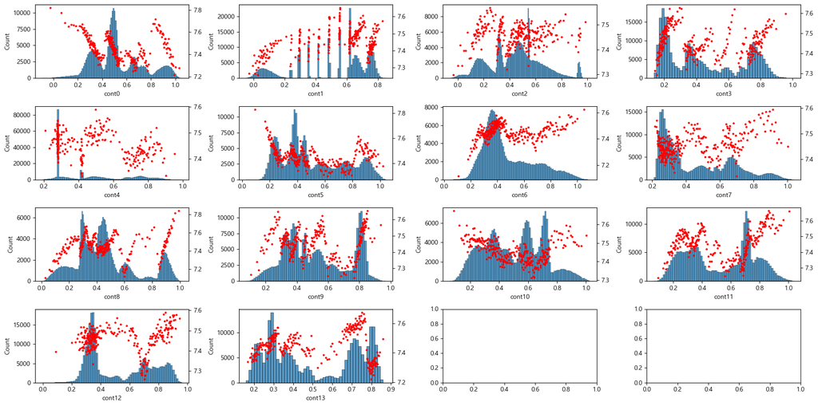

```python
'''
아래 코드는 `df_train` 데이터프레임에서 연속형 변수 `cont0`부터 `cont13`까지의 히스토그램과 각 변수의 구간별 `target` 평균을 시각화합니다.
각 변수에 대해 히스토그램과 `target` 평균을 같은 그래프에 나타내어, 변수 분포와 `target` 값 간의 관계를 시각적으로 분석합니다.

### 1. 그래프 설정 및 초기화
- 4x4 격자의 서브플롯을 생성하여 총 16개의 서브플롯을 `axes` 배열에 저장합니다.
- 그래프의 크기를 `figsize=(18, 9)`로 설정합니다.

### 2. 반복문을 통한 변수별 시각화
- `enumerate(axes.ravel()[:14])`는 `axes` 배열을 1차원으로 펼쳐
    `cont0`부터 `cont13`까지의 14개 서브플롯에 대해 인덱스와 축(`ax`)을 순회합니다.
- 각 반복에서 변수명을 `col = 'cont{}'.format(i)`로 설정합니다.
- `sns.histplot(data=df_train, x=col, ax=ax)`는 `df_train` 데이터프레임에서
    해당 변수 `col`의 히스토그램을 생성하여 `ax` 서브플롯에 그립니다.

### 3. 구간별 `target` 평균 계산 및 시각화
- `pd.qcut(df_train[col], q=300)`은 변수 `col`을 300개의 분위 구간으로 나누고,
    이 구간을 기준으로 `df_train` 데이터프레임을 그룹화합니다.
- 각 구간별 `target` 값의 평균을 계산하여 `tmp` 데이터프레임에 저장합니다.

- `ax.twinx()`는 기존 `ax` 서브플롯과 동일한 x축을 공유하는 새로운 y축을 생성합니다.
- 각 구간의 중간값을 x축 좌표로, 해당 구간의 `target` 평균값을 y축 좌표로 설정하여
    빨간색 점(`c='r'`, `s=5`)으로 산점도를 그립니다.

### 4. 그래프 레이아웃 및 출력
- `plt.tight_layout()`는 서브플롯 간의 간격을 자동으로 조정하여 그래프들이 겹치지 않도록 합니다.
- `plt.show()`는 그래프를 화면에 출력합니다.

### 요약
- 이 코드는 4x4 격자의 서브플롯을 생성하여 `cont0`부터 `cont13`까지의
    14개 연속형 변수에 대해 히스토그램과 구간별 `target` 평균을 시각화합니다.
- 각 서브플롯에는 변수의 히스토그램과 해당 변수의 300개의 분위 구간별 `target` 평균이 빨간색 점으로 표시됩니다.
- 이 시각화를 통해 각 변수의 분포와 `target` 값 간의 관계를 시각적으로 분석할 수 있습니다.
'''

'''
아래 코드는 `pandas`의 `qcut` 기능을 사용하여 데이터를 특정 구간으로 나누고, 그 결과를 사용해
히스토그램과 `target` 변수의 평균을 시각화합니다. 여기서 `tmp.index.categories.left`는 구간의 왼쪽 경계를 의미합니다.

### 1. `index`
`index`는 `pandas`의 데이터프레임이나 시리즈에서 행(row)의 라벨을 가리킵니다.
`tmp`는 `df_train.groupby()`로 만들어진 그룹화된 결과의 평균을 담고 있는 데이터프레임이므로,
`tmp.index`는 이 데이터프레임의 행 라벨을 가리킵니다. 이 경우, `tmp.index`는 `qcut`으로 생성된 구간들로 구성됩니다.

### 2. `categories`
`qcut`은 데이터를 특정 개수의 구간으로 나누는 함수입니다.
예를 들어, `qcut`의 결과는 각 값이 속한 구간을 나타내는 `Categorical` 데이터로 반환됩니다.
`Categorical` 데이터는 여러 범주(categories)를 가지는데, 각 범주는 하나의 구간을 나타냅니다.
`tmp.index.categories`는 `qcut`에 의해 생성된 구간들을 의미합니다.
각 구간은 `pd.Interval` 객체로 표현되며, 범주형 데이터의 모든 구간이 `categories` 속성으로 저장됩니다.

### 3. `left`
각 구간은 `pd.Interval` 객체로 표현되며, 이 객체는 `left`와 `right` 속성을 가집니다.
`left`는 구간의 왼쪽 경계값을 나타내고, `right`는 구간의 오른쪽 경계값을 나타냅니다.
따라서 `tmp.index.categories.left`는 `qcut`으로 생성된 모든 구간의 왼쪽 경계값들을 나열한 배열입니다.
이 값들은 구간의 중간값을 계산할 때 사용됩니다.

### 전체 흐름 요약
- `qcut`으로 데이터 구간을 나누면, 각 값은 특정 구간에 속하게 됩니다.
- `tmp.index`는 이 구간들을 나타내는 `CategoricalIndex`이며, `tmp.index.categories`는 각 구간의 범주를 나타냅니다.
- `tmp.index.categories.left`는 각 구간의 왼쪽 경계값을 모아놓은 배열입니다.

코드에서 `tmp.index.categories.left`와 `tmp.index.categories.right`의 평균을 계산해 구간의 중간값을 구한 다음,
이 중간값과 해당 구간의 `target` 변수 평균을 산점도로 그려 시각화하고 있습니다.
'''

# 다른 변수에 대해서도 그래프를 출력합니다.

fig, axes = plt.subplots(4, 4, figsize=(18, 9))
for i, ax in enumerate(axes.ravel()[:14]):
    col = 'cont{}'.format(i)
    sns.histplot(data=df_train, x=col, ax=ax)
    tmp = df_train.groupby(pd.qcut(df_train[col], q=300))[['target']].mean()
    ax.twinx().scatter((tmp.index.categories.left + tmp.index.categories.right) / 2, tmp['target'], c='r', s=5)
plt.tight_layout()
plt.show()
```

```python
'''
아래 코드는 여러 열(`cont_cols` 리스트에 저장된 열 이름들)을 포함한 데이터프레임에 대해 분위수를 계산하고,
각 분위구간에 대해 평균 `target` 값을 구하여 새로운 열을 생성하는 과정을 다룹니다.

# 0과 1 사이의 101개의 균일한 간격을 생성합니다.
q = np.arange(0, 101) / 100
이 라인은 0과 1 사이를 101개의 균일한 간격으로 나눈 배열을 생성합니다. `q`는 0.00, 0.01, 0.02, ..., 1.00의 값을 가지는 배열이 됩니다.

# cont_cols에 포함된 각 열에 대해 반복 작업을 수행합니다.
for i in cont_cols:
이 라인은 `cont_cols` 리스트에 포함된 각 열 이름에 대해 반복 작업을 시작합니다.
`cont_cols`는 `df_prob4_train` 데이터프레임의 열 이름들을 포함한 리스트입니다.

    # 각 열에 대한 분위수를 계산합니다.
    qt = df_prob4_train[i].quantile(q)
    이 라인은 현재 열 `i`에 대해 위에서 생성한 분위점 `q`를 사용하여 분위수를 계산합니다.
    `qt`는 현재 열 `i`의 분위수 값을 포함하는 시리즈가 됩니다.

    # 첫 번째 분위수보다 작은 값은 첫 번째 구간, 마지막 분위수보다 큰 값은 마지막 구간에 속하게 합니다.
    qt.iloc[[0, -1]] = (-np.inf, np.inf)
    이 라인은 `qt`의 첫 번째 값과 마지막 값을 각각 `-np.inf`와 `np.inf`로 설정하여
    첫 번째 분위수보다 작은 값은 첫 번째 구간에, 마지막 분위수보다 큰 값은 마지막 구간에 속하도록 합니다.

    # 현재 열에 대해 분위구간을 생성합니다.
    q_range = pd.cut(df_prob4_train[i], bins=qt, right=True)
    이 라인은 현재 열 `i`의 값을 `qt`에 따라 구간으로 나눕니다.
    `pd.cut` 함수는 현재 열 `i`의 값을 `qt`의 분위구간에 맞춰 구간을 나누고, 그 결과를 `q_range`에 저장합니다.
    `right=True`는 각 구간의 오른쪽 경계를 포함한다는 의미입니다.

    # 각 분위구간에 대해 target 값의 평균을 계산합니다.
    q_mean = df_prob4_train.groupby(q_range)['target'].agg('mean')
    이 라인은 `q_range`에 따라 `df_prob4_train` 데이터를 그룹화하고, 각 구간에 속하는 `target` 열의 평균을 계산합니다.
    결과는 `q_mean`에 저장됩니다. `q_mean`은 각 구간의 `target` 평균값을 포함하는 시리즈가 됩니다.

    # 현재 열에 대한 새로운 분위구간 평균값 열을 생성합니다.
    df_prob4_train[i + '_q'] = q_range.map(q_mean).astype('float')
    이 라인은 `df_prob4_train` 데이터프레임에 새로운 열을 생성합니다. 새로운 열의 이름은 현재 열 이름에 '_q'를 붙인 형태이며,
    `q_range` 값을 `q_mean` 값으로 매핑한 결과를 저장합니다. `astype('float')`은 결과를 float 형식으로 변환합니다.

    # 테스트 데이터에 대해서도 동일한 작업을 수행하여 새로운 분위구간 평균값 열을 생성합니다.
    df_prob4_test[i + '_q'] = pd.cut(df_prob4_test[i], bins=qt, right=True).map(q_mean).astype('float')
    이 라인은 `df_prob4_test` 데이터프레임에 대해 동일한 작업을 수행합니다.
    `df_prob4_test`의 현재 열 `i` 값을 `qt`에 따라 구간으로 나누고,
    각 구간에 대해 `q_mean`의 값을 매핑하여 새로운 열을 생성합니다.
    새로운 열의 이름은 `df_prob4_train`과 동일하게 현재 열 이름에 '_q'를 붙인 형태입니다.

### 전체 과정 요약
1. 0과 1 사이의 101개의 균일한 점을 생성합니다.
2. `cont_cols` 리스트에 포함된 각 열에 대해 반복 작업을 수행합니다.
3. 현재 열의 분위수를 계산합니다.
4. 첫 번째 분위수보다 작은 값은 첫 번째 구간, 마지막 분위수보다 큰 값은 마지막 구간에 속하도록 설정합니다.
5. 현재 열의 값을 분위수에 따라 구간으로 나눕니다.
6. 각 구간에 속하는 `target` 값의 평균을 계산합니다.
7. `df_prob4_train` 데이터프레임에 새로운 열을 생성하고, 각 값이 속하는 구간의 `target` 평균값으로 대체합니다.
8. `df_prob4_test` 데이터프레임에 대해 동일한 작업을 수행하여 새로운 열을 생성합니다.

이 과정을 통해 각 열에 대해 분위구간을 기반으로 한 새로운 특성을 생성할 수 있습니다.
이는 모델의 성능을 향상시키기 위해 유용한 전처리 방법입니다.
'''

q = np.arange(0, 101) / 100
for i in cont_cols:
    qt = df_prob4_train[i].quantile(q)
    qt.iloc[[0, -1]] = (-np.inf, np.inf)
    q_range = pd.cut(df_prob4_train[i], bins=qt, right=True)
    q_mean = df_prob4_train.groupby(q_range)['target'].agg('mean')

    df_prob4_train[i + '_q'] = q_range.map(q_mean).astype('float')
    df_prob4_test[i + '_q'] = pd.cut(df_prob4_test[i], bins=qt, right=True).map(q_mean).astype('float')

print('df_prob4_train.columns = ', df_prob4_train.columns)
print('df_prob4_test.columns = ', df_prob4_test.columns)
```

```
df_prob4_train.columns =  Index(['cont0', 'cont1', 'cont2', 'cont3', 'cont4', 'cont5', 'cont6', 'cont7',
       'cont8', 'cont9', 'cont10', 'cont11', 'cont12', 'cont13', 'target',
       'targetA', 'cat0_A', 'cat0_B', 'cat1_A', 'cat1_B', 'cat2_A', 'cat2_B',
       'cat3_A', 'cat3_C', 'cat3_D', 'cat4_B', 'cat4_C', 'cat5_A', 'cat5_B',
       'cat5_C', 'cat5_D', 'cat6_A', 'cat6_B', 'cat6_C', 'cat7_B', 'cat7_D',
       'cat7_E', 'cat7_G', 'cat8_A', 'cat8_C', 'cat8_D', 'cat8_E', 'cat8_G',
       'cat9_A', 'cat9_B', 'cat9_F', 'cat9_G', 'cat9_H', 'cat9_I', 'cat9_J',
       'cat9_K', 'cat9_L', 'cat9_M', 'cat9_N', 'cat9_O', 'cont0_q', 'cont1_q',
       'cont2_q', 'cont3_q', 'cont4_q', 'cont5_q', 'cont6_q', 'cont7_q',
       'cont8_q', 'cont9_q', 'cont10_q', 'cont11_q', 'cont12_q', 'cont13_q'],
      dtype='object')
df_prob4_test.columns =  Index(['cont0', 'cont1', 'cont2', 'cont3', 'cont4', 'cont5', 'cont6', 'cont7',
       'cont8', 'cont9', 'cont10', 'cont11', 'cont12', 'cont13', 'target',
       'targetA', 'cat0_A', 'cat0_B', 'cat1_A', 'cat1_B', 'cat2_A', 'cat2_B',
       'cat3_A', 'cat3_C', 'cat3_D', 'cat4_B', 'cat4_C', 'cat5_A', 'cat5_B',
       'cat5_C', 'cat5_D', 'cat6_A', 'cat6_B', 'cat6_C', 'cat7_B', 'cat7_D',
       'cat7_E', 'cat7_G', 'cat8_A', 'cat8_C', 'cat8_D', 'cat8_E', 'cat8_G',
       'cat9_A', 'cat9_B', 'cat9_F', 'cat9_G', 'cat9_H', 'cat9_I', 'cat9_J',
       'cat9_K', 'cat9_L', 'cat9_M', 'cat9_N', 'cat9_O', 'cont0_q', 'cont1_q',
       'cont2_q', 'cont3_q', 'cont4_q', 'cont5_q', 'cont6_q', 'cont7_q',
       'cont8_q', 'cont9_q', 'cont10_q', 'cont11_q', 'cont12_q', 'cont13_q'],
      dtype='object')
```

```python
'''
`pandas`의 `between()` 함수는 데이터프레임이나 시리즈의 값들이 특정 범위 내에 속하는지 여부를 판별하는 데 사용됩니다.
이 함수는 범위를 설정하고, 해당 범위 내에 포함되는 값들을 불리언 값(`True` 또는 `False`)으로 반환합니다.

### `between()` 함수의 주요 요소들

#### 1. 인자 (Parameters)
`between()` 함수는 다음과 같은 인자들을 가집니다:
- `left`:
  - 범위의 하한값 (inclusive).
  - 이 값 이상인 요소들이 `True`로 표시됩니다.
  - 기본값은 필수 입력값입니다.
- `right`:
  - 범위의 상한값 (inclusive).
  - 이 값 이하인 요소들이 `True`로 표시됩니다.
  - 기본값은 필수 입력값입니다.
- `inclusive`:
  - 경계값 포함 여부를 설정합니다.
  - 기본값은 `'both'`로, 하한값(`left`)과 상한값(`right`) 모두 포함합니다.
  - 설정 가능한 값:
    - `'both'`: 하한값과 상한값 모두 포함 (기본값)
    - `'neither'`: 하한값과 상한값 모두 제외
    - `'left'`: 하한값만 포함하고 상한값은 제외
    - `'right'`: 상한값만 포함하고 하한값은 제외

#### 2. 리턴값 (Return Value)
- `Series` (또는 `DataFrame`, 원본이 `DataFrame`인 경우):
  - `left`와 `right` 사이에 있는 값에 대해 `True`, 그렇지 않은 값에 대해 `False` 값을 가지는 `Series` 객체를 반환합니다.
  - 원본의 인덱스를 유지하며, 각 요소는 해당 범위 내에 속하는지 여부를 나타냅니다.

#### 3. 속성 (Attributes)
`between()` 함수 자체는 속성을 가지지 않습니다. 그러나 이 함수가 적용되는 대상(`Series` 또는 `DataFrame`)에는 속성이 존재할 수 있습니다.

#### 4. 함수 (Methods)
`between()` 함수는 다른 `pandas` 함수와 결합하여 사용될 수 있으며, 이를 통해 다양한 데이터 조작이 가능합니다.
예를 들어, `DataFrame.loc[]`와 결합하여 특정 조건에 맞는 행을 선택할 수 있습니다.

### 예제

import pandas as pd

# 데이터 생성
data = {'A': [1, 2, 3, 4, 5],
        'B': [10, 20, 30, 40, 50]}

df = pd.DataFrame(data)

# 'A' 열의 값이 2 이상 4 이하인 행 선택
mask = df['A'].between(left=2, right=4)
filtered_df = df[mask]

print(filtered_df)

위 코드에서는 `df['A']`의 값들이 2 이상 4 이하인 행들만 `filtered_df`에 저장됩니다.

#### inclusive 사용 예제:

mask = df['A'].between(left=2, right=4, inclusive='neither')
위 예제에서는 2보다 크고 4보다 작은 값만 `True`로 판별됩니다.

### 요약
- `between()` 함수는 `Series` 또는 `DataFrame`의 값들이 특정 범위 내에 있는지 확인할 때 사용됩니다.
- `left`와 `right` 인자를 통해 범위를 설정하고, `inclusive` 인자를 통해 경계값 포함 여부를 지정할 수 있습니다.
- `Series` 객체를 반환하며, 각 요소에 대해 `True` 또는 `False` 값을 가집니다.

'''

import pandas as pd

# 데이터 생성
data = {'A': [1, 2, 3, 4, 5],
        'B': [10, 20, 30, 40, 50]}

df = pd.DataFrame(data)

# 'A' 열의 값이 2 이상 4 이하인 행 선택
mask = df['A'].between(left=2, right=4)
filtered_df = df[mask]

print(filtered_df)
print('--------------------------------------')

mask2 = df['A'].between(left=2, right=4, inclusive='neither')
filtered_df2 = df[mask2]

# 만약 여러분의 코드가 inclusive='neither'로 설정되어 있는데, 그럼에도 불구하고 양 끝 값이 포함된다면,
# 사용 중인 pandas 버전이 1.3.0보다 낮을 가능성이 있습니다.
print(filtered_df2)
```

```
   A   B
1  2  20
2  3  30
3  4  40
--------------------------------------
   A   B
1  2  20
2  3  30
3  4  40
```

```python
'''
아래 코드는 여러 열(`cont_cols` 리스트에 저장된 열 이름들)을 포함한 데이터프레임에 대해 분위수를 계산하고,
테스트 데이터의 값이 훈련 데이터의 분위구간에 포함되지 않는 경우를 확인하는 과정을 다룹니다.

# 0과 1 사이의 101개의 균일한 간격을 생성합니다.
q = np.arange(0, 101) / 100
이 라인은 0과 1 사이를 101개의 균일한 간격으로 나눈 배열을 생성합니다. `q`는 0.00, 0.01, 0.02, ..., 1.00의 값을 가지는 배열이 됩니다.

# cont_cols에 포함된 각 열에 대해 반복 작업을 수행합니다.
for i in cont_cols:
이 라인은 `cont_cols` 리스트에 포함된 각 열 이름에 대해 반복 작업을 시작합니다.
`cont_cols`는 `df_prob4_train` 데이터프레임의 열 이름들을 포함한 리스트입니다.

    # 각 열에 대한 분위수를 계산합니다.
    qt = df_prob4_train[i].quantile(q)
    이 라인은 현재 열 `i`에 대해 위에서 생성한 분위점 `q`를 사용하여 분위수를 계산합니다.
    `qt`는 현재 열 `i`의 분위수 값을 포함하는 시리즈가 됩니다.

    # 현재 열에 대해 분위구간을 생성합니다.
    q_range = pd.cut(df_prob4_train[i], bins=qt, right=True)
    이 라인은 현재 열 `i`의 값을 `qt`에 따라 구간으로 나눕니다.
    `pd.cut` 함수는 현재 열 `i`의 값을 `qt`의 분위구간에 맞춰 구간을 나누고, 그 결과를 `q_range`에 저장합니다.
    `right=True`는 각 구간의 오른쪽 경계를 포함한다는 의미입니다.

    # 테스트 데이터에서 분위구간에 포함되지 않는 값들을 확인합니다.
    q_range_t = pd.cut(df_prob4_test[i], bins=qt, right=True).isna()
    이 라인은 `df_prob4_test` 데이터프레임의 현재 열 `i` 값을 `qt`에 따라 구간으로 나누고,
    각 값이 구간에 포함되지 않는지를 확인합니다.
    `pd.cut(df_prob4_test[i], bins=qt, right=True)`는 `df_prob4_test`의 현재 열 값을 `qt`의 분위구간에 맞춰 구간을 나누고,
    `isna()`는 해당 값이 구간에 포함되지 않으면 `True`, 포함되면 `False`를 반환합니다. 결과는 `q_range_t`에 저장됩니다.

    # 테스트 데이터의 값이 훈련 데이터의 최소값과 최대값 사이에 있는지 확인합니다.
    notin_range_t = ~df_prob4_test[i].between(*df_prob4_train[i].agg(['min', 'max']))
    이 라인은 `df_prob4_test`의 현재 열 `i` 값이 `df_prob4_train`의 현재 열 `i` 값의 최소값과 최대값 사이에 있는지 확인합니다.
    `between(*df_prob4_train[i].agg(['min', 'max']))`는 값이 최소값과 최대값 사이에 있으면 `True`,
    그렇지 않으면 `False`를 반환합니다. `~` 연산자는 `True`와 `False`를 반대로 바꿉니다. 결과는 `notin_range_t`에 저장됩니다.

    # 열 이름, 분위구간에 포함되지 않는 값의 개수, 최소/최대값 사이에 포함되지 않는 값의 개수,
    # 두 기준이 다른 값의 개수를 출력합니다.
    print(i, q_range_t.sum(), notin_range_t.sum(), (q_range_t != notin_range_t).sum())
    이 라인은 현재 열 이름, `q_range_t`에서 `True`인 값의 개수 (즉, 분위구간에 포함되지 않는 값의 개수),
    `notin_range_t`에서 `True`인 값의 개수 (즉, 최소값과 최대값 사이에 포함되지 않는 값의 개수),
    `q_range_t`와 `notin_range_t`가 다른 값의 개수를 출력합니다.

### 전체 과정 요약
1. 0과 1 사이의 101개의 균일한 점을 생성합니다.
2. `cont_cols` 리스트에 포함된 각 열에 대해 반복 작업을 수행합니다.
3. 현재 열의 분위수를 계산합니다.
4. 현재 열의 값을 분위수에 따라 구간으로 나눕니다.
5. 테스트 데이터에서 각 값이 구간에 포함되지 않는지를 확인합니다.
6. 테스트 데이터의 값이 훈련 데이터의 최소값과 최대값 사이에 있는지를 확인합니다.
7. 현재 열 이름, 분위구간에 포함되지 않는 값의 개수, 최소/최대값 사이에 포함되지 않는 값의 개수,
    두 기준이 다른 값의 개수를 출력합니다.

이 과정을 통해 테스트 데이터의 값이 훈련 데이터의 분위구간이나 최소/최대값 범위를 벗어나는 경우를 확인할 수 있습니다.
이를 통해 데이터의 분포를 이해하고, 모델링 전에 데이터의 이상치를 파악할 수 있습니다.
'''

# Q: 범위를 확장하지 않을 때, Test에서 nan 값은 train의 최소값 또는 최대값의 큰값이 맞나요?
# A: 보여드립니다.
q = np.arange(0, 101) / 100

for i in cont_cols:
    qt = df_prob4_train[i].quantile(q)
    q_range = pd.cut(df_prob4_train[i], bins=qt, right=True)
    q_range_t = pd.cut(df_prob4_test[i], bins=qt, right=True).isna()
    notin_range_t = ~df_prob4_test[i].between(*df_prob4_train[i].agg(['min', 'max']))
    print(i, q_range_t.sum(), notin_range_t.sum(), (q_range_t != notin_range_t).sum())
    print('------------------------------------------------------------------------------')
```

```
cont0 0 0 0
------------------------------------------------------------------------------
cont1 0 0 0
------------------------------------------------------------------------------
cont2 0 0 0
------------------------------------------------------------------------------
cont3 0 0 0
------------------------------------------------------------------------------
cont4 0 0 0
------------------------------------------------------------------------------
cont5 1 1 0
------------------------------------------------------------------------------
cont6 1 1 0
------------------------------------------------------------------------------
cont7 0 0 0
------------------------------------------------------------------------------
cont8 1 1 0
------------------------------------------------------------------------------
cont9 0 0 0
------------------------------------------------------------------------------
cont10 1 1 0
------------------------------------------------------------------------------
cont11 0 0 0
------------------------------------------------------------------------------
cont12 2 2 0
------------------------------------------------------------------------------
cont13 0 0 0
------------------------------------------------------------------------------
```

```python
# 위 2개 코드 비교
'''
두 코드 모두 `df_prob4_train`과 `df_prob4_test` 데이터프레임에서
연속형 변수(`cont_cols`)의 분위수를 구간으로 나누고, 각 구간의 `target` 값의 평균을 구하여
새로운 변수를 생성하는 작업을 수행합니다. 그러나 두 코드의 목적과 동작 방식에는 차이가 있습니다.

### 첫 번째 코드
코드는 각 연속형 변수에 대해 100개의 분위 구간을 만들고, 해당 구간의 `target` 값의 평균을 새로운 변수로 추가합니다.

### 동작 설명
1. `np.arange(0, 101) / 100`을 사용하여 0부터 1까지 101개의 균등한 값을 생성합니다.
2. 각 연속형 변수 `i`에 대해:
   - `qt`에 해당 변수의 분위수를 저장합니다.
   - 첫 번째와 마지막 분위수를 `-np.inf`와 `np.inf`로 설정하여 모든 값을 포함하도록 합니다.
   - `pd.cut`을 사용하여 df_prob4_train[i]의 값을 100개의 분위 구간으로 나눕니다.
   - 구간별로 `target` 값의 평균을 계산합니다.
   - `df_prob4_train`과 `df_prob4_test` 데이터프레임에 새로운 변수로 구간별 평균 값을 추가합니다.

### 두 번째 코드
코드는 `df_prob4_test` 데이터의 값들이 `df_prob4_train` 데이터의 분위 구간 밖에 있는지를 검사하는 용도로 사용됩니다.

### 동작 설명
1. 첫 번째 코드와 동일하게 `np.arange(0, 101) / 100`을 사용하여 0부터 1까지 101개의 균등한 값을 생성합니다.
2. 각 연속형 변수 `i`에 대해:
   - `qt`에 해당 변수의 분위수를 저장합니다.
   - `pd.cut`을 사용하여 `df_prob4_train` 데이터프레임의 변수를 분위 구간으로 나눕니다.
   - `df_prob4_test` 데이터에서 분위 구간에 속하지 않는 값들을 `isna()`를 통해 확인합니다.
   - `df_prob4_test` 데이터에서 `df_prob4_train` 데이터의
       최소값과 최대값 범위를 벗어난 값들을 `between` 메서드를 통해 확인합니다.
   - 변수 `i`에 대해 `df_prob4_test` 데이터에서 분위 구간 밖의 값과 최소-최대 범위를 벗어난 값의 수를 출력합니다.

### 두 코드의 차이점 비교
1. 목적:
   - 첫 번째 코드는 `target` 값의 구간별 평균을 계산하여
       새로운 변수를 생성합니다. 이 변수를 모델에 사용할 수 있도록 준비하는 과정입니다.
   - 두 번째 코드는 `df_prob4_test` 데이터의 값들이 `df_prob4_train` 데이터의
       분위 구간 밖에 있는지를 확인하고, 이를 통해 데이터의 범위가 적절한지 검사하는 용도입니다.

2. 동작 방식:
   - 첫 번째 코드는 각 변수의 분위 구간을 생성하고, 구간별 `target` 값의 평균을 새로운 변수로 추가합니다.
   - 두 번째 코드는 각 변수의 분위 구간을 생성하고,
       `df_prob4_test` 데이터에서 해당 분위 구간 밖에 있는 값을 검사하여 출력합니다.

3. 출력 결과:
   - 첫 번째 코드는 새로운 변수를 `df_prob4_train`과 `df_prob4_test` 데이터프레임에 추가합니다.
   - 두 번째 코드는 각 변수에 대해 `df_prob4_test` 데이터에서
       분위 구간 밖의 값과 최소-최대 범위를 벗어난 값의 수를 출력합니다.

결론적으로, 첫 번째 코드는 모델링을 위한 데이터 전처리 작업을 수행하며,
두 번째 코드는 테스트 데이터의 분포가 학습 데이터와 일치하는지 확인하는 작업을 수행합니다.
'''
print('')
```

```python
df_prob4_train.head()
```

| id | cont0 | cont1 | cont2 | cont3 | cont4 | cont5 | cont6 | cont7 | cont8 | cont9 | ... | cont4_q | cont5_q | cont6_q | cont7_q | cont8_q | cont9_q | cont10_q | cont11_q | cont12_q | cont13_q |
| --- | --- | --- | --- | --- | --- | --- | --- | --- | --- | --- | --- | --- | --- | --- | --- | --- | --- | --- | --- | --- | --- |
| 487693 | 0.49355 | 0.69104 | 0.66940 | 0.46424 | 0.78825 | 0.34951 | 0.30596 | 0.69445 | 0.19411 | 0.35497 | ... | 7.444439 | 7.507718 | 7.418108 | 7.424195 | 7.466343 | 7.391288 | 7.494510 | 7.489119 | 7.450950 | 7.357680 |
| 307175 | 0.66260 | 0.55180 | 0.31117 | 0.83165 | 0.22354 | 0.34808 | 0.65781 | 0.30914 | 0.48613 | 0.59179 | ... | 7.464061 | 7.507718 | 7.447277 | 7.431217 | 7.424309 | 7.305747 | 7.434794 | 7.436207 | 7.481821 | 7.426932 |
| 493409 | 0.87161 | 0.69037 | 0.33452 | 0.69755 | 0.28069 | 0.93415 | 0.63591 | 0.87033 | 0.93617 | 0.79620 | ... | 7.462176 | 7.471819 | 7.454580 | 7.537384 | 7.684391 | 7.384950 | 7.377006 | 7.615075 | 7.558415 | 7.483465 |
| 414858 | 0.51951 | 0.03523 | 0.32366 | 0.38940 | 0.41430 | 0.73061 | 0.37822 | 0.62359 | 0.34185 | 0.38249 | ... | 7.371190 | 7.354649 | 7.498205 | 7.464006 | 7.428804 | 7.437616 | 7.456432 | 7.375974 | 7.447048 | 7.438021 |
| 408161 | 0.86293 | 0.61935 | 0.70905 | 0.82617 | 0.41898 | 0.43902 | 0.31892 | 0.58007 | 0.37662 | 0.37795 | ... | 7.406167 | 7.465528 | 7.446922 | 7.391109 | 7.546018 | 7.418989 | 7.426295 | 7.338579 | 7.514672 | 7.337787 |

5 rows × 69 columns

```python
df_prob4_test.head()
```

| id | cont0 | cont1 | cont2 | cont3 | cont4 | cont5 | cont6 | cont7 | cont8 | cont9 | ... | cont4_q | cont5_q | cont6_q | cont7_q | cont8_q | cont9_q | cont10_q | cont11_q | cont12_q | cont13_q |
| --- | --- | --- | --- | --- | --- | --- | --- | --- | --- | --- | --- | --- | --- | --- | --- | --- | --- | --- | --- | --- | --- |
| 309145 | 0.93484 | 0.29862 | 0.12013 | 0.71414 | 0.27825 | 1.01559 | 0.54047 | 0.80249 | 0.90302 | 0.80604 | ... | 7.464230 | 7.412962 | 7.417744 | 7.516305 | 7.529983 | 7.499738 | 7.430453 | 7.613589 | 7.514672 | 7.612053 |
| 368647 | 0.32245 | 0.35401 | 0.41031 | 0.75546 | 0.34427 | 0.25169 | 0.30402 | 0.33034 | 0.20197 | 0.37512 | ... | 7.471364 | 7.451470 | 7.418108 | 7.397414 | 7.466594 | 7.422375 | 7.506085 | 7.521223 | 7.505129 | 7.355018 |
| 487072 | 0.47681 | 0.74517 | 0.71498 | 0.20361 | 0.49142 | 0.43309 | 0.68805 | 0.23303 | 0.38456 | 0.38120 | ... | 7.492398 | 7.485158 | 7.363892 | 7.469959 | 7.572538 | 7.437616 | 7.412831 | 7.433720 | 7.462790 | 7.347919 |
| 490811 | 0.46057 | 0.35253 | 0.68699 | 0.43218 | 0.28081 | 0.37182 | 0.38092 | 0.58439 | 0.45705 | 0.47263 | ... | 7.463842 | 7.503739 | 7.483065 | 7.391109 | 7.388975 | 7.396864 | 7.548061 | 7.524618 | 7.471193 | 7.291734 |
| 484687 | 0.95435 | 0.48605 | 0.33035 | 0.79471 | 0.48517 | 0.23492 | 0.79788 | 0.65686 | 0.63854 | 0.24914 | ... | 7.473854 | 7.473077 | 7.523299 | 7.494512 | 7.365279 | 7.531100 | 7.383531 | 7.434598 | 7.491298 | 7.598639 |

5 rows × 69 columns

## 단계 4-5

prob4_train에서 target을 대상으로 선형회귀모델을 학습하고,

prob4_test를 다음 지표로 성능 평가한 값을 D라고 한다.

선형회귀 모델은 아래와 같은 손실함수로 학습을 한다.

$||Xw - y||^2_2 + \alpha||w||^2_2, \alpha = 0.1$

Hint] sklearn.linear_model.Ridge 또는 Lasso 중 요건에 맞는 것을 사용한다.

입력 변수: cont0_q ~ cont13_q, cat0 ~ 9까지 원핫-인코딩 후 나온 파생 변수

(변수명 다음 범주명으로 알파벳 순서이다)

대상 변수: target

성능 지표: $MSE(Y, \hat{Y}) = \frac{1}{n}\sum^{n}_{i=1}(y_i-\hat{y_i})^2$

```python
'''
`Ridge`는 `scikit-learn` 라이브러리에서 제공하는 선형 회귀 모델로, L2 정규화를 적용하여 모델의 복잡도를 제어합니다.
정규화는 과적합을 방지하고, 특성이 많은 데이터셋에서 모델의 일반화 성능을 향상시킵니다.

### 1. 인자 (Parameters)
- `alpha`:
  - 정규화 강도를 조절하는 매개변수로, 기본값은 `1.0`입니다.
  - 값이 클수록 더 강한 정규화가 적용되며, 회귀 계수의 크기가 작아집니다.
  - `alpha=0`이면 일반 선형 회귀와 동일하게 동작합니다.
- `fit_intercept`:
  - 절편을 학습할지 여부를 결정하는 플래그입니다. 기본값은 `True`입니다.
  - `True`이면 절편을 학습하고, `False`이면 절편을 사용하지 않습니다.
- `normalize` (Deprecated since version 1.0):
  - 이 인자는 `fit_intercept`가 `True`일 때, 특성을 정규화할지 여부를 결정합니다.
  - 기본값은 `False`입니다.
  - 현재는 사용되지 않으며, `preprocessing.StandardScaler`를 사용하는 것이 권장됩니다.
- `copy_X`:
  - `True`이면 원본 데이터 `X`의 복사본을 사용하고, `False`이면 원본 데이터를 덮어쓰지 않습니다.
  - 기본값은 `True`입니다.
- `max_iter`:
  - 알고리즘이 수렴할 때까지의 최대 반복 횟수입니다.
  - 기본값은 `None`이며, 기본 반복 횟수는 `scikit-learn`의 내부 설정에 따릅니다.
- `tol`:
  - 반복 과정의 종료 기준이 되는 허용 오차입니다. 기본값은 `1e-3`입니다.
- `solver`:
  - 최적화에 사용할 알고리즘을 선택합니다.
  - 옵션: `'auto'`, `'svd'`, `'cholesky'`, `'lsqr'`, `'sparse_cg'`, `'sag'`, `'saga'`
  - 기본값은 `'auto'`이며, 데이터셋에 따라 적절한 솔버를 자동으로 선택합니다.
- `random_state`:
  - 재현성을 위해 난수 발생기의 시드를 설정합니다. `solver`가 `'sag'` 또는 `'saga'`일 때만 사용됩니다.
- `positive`:
  - `True`로 설정하면 회귀 계수가 양수로 제한됩니다.
  - 기본값은 `False`입니다.

### 2. 리턴값 (Return Value)
`Ridge` 클래스는 자체적으로 리턴값을 가지지 않지만, 모델 객체를 생성하여 리턴합니다.
이 모델 객체는 학습 후 회귀 계수, 예측값 등을 제공합니다.

### 3. 속성 (Attributes)
- `coef_`:
  - 학습된 회귀 계수 벡터입니다.
  - 모델이 학습된 후 사용할 수 있습니다.
- `intercept_`:
  - 학습된 절편입니다. `fit_intercept=True`일 때만 사용됩니다.
- `n_iter_`:
  - `solver`가 반복 알고리즘(`'sag'`, `'saga'`, `'lsqr'`, `'sparse_cg'`)일 때, 반복 횟수를 나타냅니다.

### 4. 함수 (Methods)
`Ridge` 클래스는 다음과 같은 주요 메서드를 제공합니다:
- `fit(X, y)`:
  - 모델을 학습시킵니다.
  - `X`는 특성 행렬, `y`는 타겟 벡터입니다.
  - 모델이 학습된 후 `coef_`와 `intercept_`가 결정됩니다.
- `predict(X)`:
  - 학습된 모델을 사용하여 새로운 데이터 `X`에 대한 예측을 수행합니다.
  - `X`는 특성 행렬이며, 예측된 타겟 벡터를 반환합니다.
- `score(X, y)`:
  - 모델의 성능을 평가합니다. R² 점수를 계산하여 반환합니다.
  - 1에 가까울수록 모델이 타겟 값을 잘 설명합니다.
- `get_params(deep=True)`:
  - 모델의 파라미터를 딕셔너리로 반환합니다.
  - `deep=True`이면 하위 객체의 파라미터도 포함합니다.
- `set_params(params)`:
  - 모델의 파라미터를 설정합니다. `params`는 키-값 쌍으로 전달됩니다.
'''

### 예제
from sklearn.linear_model import Ridge
from sklearn.datasets import make_regression
from sklearn.model_selection import train_test_split

# 데이터 생성
X, y = make_regression(n_samples=100, n_features=2, noise=0.1, random_state=42)
X_train, X_test, y_train, y_test = train_test_split(X, y, test_size=0.2, random_state=42)

# Ridge 회귀 모델 생성 및 학습
ridge_model = Ridge(alpha=1.0)
ridge_model.fit(X_train, y_train)

# 예측 및 평가
predictions = ridge_model.predict(X_test)
score = ridge_model.score(X_test, y_test)

print(f"Ridge 회귀 계수: {ridge_model.coef_}")
print(f"R² 점수: {score}")
```

```
Ridge 회귀 계수: [86.36361962 73.19145993]
R² 점수: 0.9998060779667833
```

```python
'''
코드는 Ridge 회귀 모델을 사용하여 학습 및 예측을 수행하고, 모델의 성능을 평가합니다.

### 코드 설명

1. Ridge 회귀 모델 생성
   - `Ridge` 클래스는 L2 정규화를 사용한 회귀 모델을 생성합니다.
   - `alpha=0.1`은 정규화 강도를 조절하는 하이퍼파라미터입니다. 값이 클수록 더 강한 정규화를 적용합니다.

2. 특징 변수 선택
   - `X_rd`는 모델에 사용할 특징 변수 목록을 정의합니다.
   - `[i + '_q' for i in cont_cols]`는 모든 연속형 변수(`cont_cols`)에 대한 분위 구간별 평균 값을 포함합니다.
   - `dum_cols`는 범주형 변수의 원-핫 인코딩된 열 이름을 포함합니다.

3. 모델 학습
   - `df_prob4_train[X_rd]` 데이터프레임의 `X_rd` 변수들을 사용하여 `target` 변수를 예측하도록 모델을 학습시킵니다.

4. 테스트 데이터에 대한 예측 및 평가
   - `reg_rd.predict(df_prob4_test[X_rd])`는 테스트 데이터
       `df_prob4_test[X_rd]`에 대해 학습된 Ridge 모델을 사용하여 예측 값을 생성합니다.
   - `mean_squared_error(df_prob4_test['target'], ...)`는 테스트 데이터의
       실제 `target` 값과 예측 값 간의 평균 제곱 오차(MSE)를 계산합니다.
   - `D`는 테스트 데이터에 대한 MSE 값을 저장합니다.

5. 모델 성능 평가
   - `D`는 테스트 데이터의 MSE 값입니다.
   - `mean_squared_error(df_prob4_train['target'], reg_rd.predict(df_prob4_train[X_rd]))`는
        학습 데이터의 실제 `target` 값과 예측 값 간의 MSE를 계산합니다.
   - 두 값을 튜플 형태로 반환하여 학습 데이터와 테스트 데이터에 대한 MSE를 비교합니다.

### 코드가 동작하는 내용 요약
- Ridge 회귀 모델을 생성하고 정규화 강도를 설정합니다 (`alpha=0.1`).
- 모델에 사용할 특징 변수를 선택합니다 (`X_rd`).
- 학습 데이터를 사용하여 모델을 학습시킵니다.
- 테스트 데이터에 대한 예측을 수행하고, 예측 값과 실제 값 간의 평균 제곱 오차를 계산하여 모델의 성능을 평가합니다.
- 학습 데이터와 테스트 데이터에 대한 MSE를 비교하여 모델의 성능을 확인합니다.
'''

from sklearn.linear_model import Ridge
from sklearn.metrics import mean_squared_error

reg_rd = Ridge(alpha=0.1)
X_rd = [i + '_q' for i in cont_cols] + dum_cols
print('X_rd = ', X_rd)
print('------------------------------------------------------------------------------')

reg_rd.fit(df_prob4_train[X_rd], df_prob4_train['target'])

D = mean_squared_error(df_prob4_test['target'], reg_rd.predict(df_prob4_test[X_rd]))
(
    D,
    mean_squared_error(df_prob4_train['target'], reg_rd.predict(df_prob4_train[X_rd]))
)
```

```
X_rd =  ['cont0_q', 'cont1_q', 'cont2_q', 'cont3_q', 'cont4_q', 'cont5_q', 'cont6_q', 'cont7_q', 'cont8_q', 'cont9_q', 'cont10_q', 'cont11_q', 'cont12_q', 'cont13_q', 'cat0_B', 'cat1_B', 'cat2_B', 'cat3_C', 'cat3_D', 'cat4_C', 'cat5_B', 'cat5_C', 'cat5_D', 'cat6_B', 'cat6_C', 'cat7_D', 'cat7_E', 'ca…
------------------------------------------------------------------------------
```

```
(0.7211658399136691, 0.7133971363485151)
```

```python
D, round(D, 2)
```

```
(0.7211658399136691, 0.72)
```

D를 소수점 셋째 자리에서 반올림하여 둘째 자리까지 출력하라.

**0.72**

```python
'''
`cross_val_score()` 함수는 Scikit-learn 라이브러리에서 제공하는 함수로,
교차 검증(cross-validation)을 통해 모델의 성능을 평가할 때 사용됩니다.
이 함수는 주어진 데이터셋을 여러 개의 폴드(folds)로 나누고, 각 폴드에 대해 모델을 훈련 및 평가하여 성능을 반환합니다.

### `cross_val_score()` 함수의 주요 인자
1. `estimator`:
   - 학습에 사용될 모델 객체입니다. `estimator`는 `fit` 메서드를 가지고 있어야 하며,
       예측을 위해 `predict` 또는 `predict_proba` 메서드를 지원해야 합니다.
   - 예: `estimator=LinearRegression()`, `estimator=RandomForestClassifier()`
2. `X`:
   - 모델을 훈련시키기 위한 피처(features) 데이터입니다. 일반적으로 2차원 배열 또는 판다스 데이터프레임으로 제공됩니다.
   - 예: `X = df[['feature1', 'feature2']]`
3. `y`:
   - 모델의 타겟 값 또는 레이블(label) 데이터입니다. 1차원 배열이나 판다스 시리즈로 제공됩니다.
   - 예: `y = df['target']`
4. `scoring` (선택 사항):
   - 모델의 성능을 평가할 지표를 정의합니다. 문자열(예: `'accuracy'`, `'f1'`, `'roc_auc'`) 또는 함수로 지정할 수 있습니다.
   - 지정하지 않으면 기본적으로 `estimator`의 `score` 메서드가 사용됩니다.
   - 예: `scoring='accuracy'`, `scoring='neg_mean_squared_error'`
5. `cv` (선택 사항):
   - 교차 검증에서 사용할 폴드의 개수 또는 교차 검증 분할 전략입니다. 기본값은 `5`입니다.
   - `cv`는 정수, `KFold` 객체, `StratifiedKFold` 객체, 또는 사용자 정의 분할 전략일 수 있습니다.
   - 예: `cv=5`, `cv=StratifiedKFold(n_splits=10)`
6. `n_jobs` (선택 사항):
   - 병렬 처리를 위해 사용할 CPU 코어 수를 지정합니다. `-1`로 설정하면 모든 가용 코어를 사용합니다.
   - 예: `n_jobs=-1`
7. `verbose` (선택 사항):
   - 실행 중 출력되는 정보의 양을 조절합니다. 큰 값일수록 더 많은 정보가 출력됩니다.
   - 예: `verbose=1`
8. `fit_params` (선택 사항):
   - 모델 학습 시 추가적으로 전달할 매개변수를 사전 형태로 제공합니다.
   - 예: `fit_params={'early_stopping_rounds': 10}`
9. `pre_dispatch` (선택 사항):
   - 작업을 분할하여 미리 할당할 수 있는 수를 조절하는 매개변수입니다. 기본값은 `'2*n_jobs'`입니다.

### `cross_val_score()` 함수의 리턴값
- 리턴값:
  - 모델의 각 폴드에서 계산된 점수의 리스트가 담긴 1차원 NumPy 배열을 반환합니다.
  - 예: `array([0.75, 0.82, 0.78, 0.80, 0.77])`

### 주요 속성 및 함수
`cross_val_score()`는 리턴값을 통해 주어진 모델의 성능을 평가하는 데 사용되며, 다음과 같은 속성 및 함수와 함께 사용될 수 있습니다:
1. `mean()`:
   - 교차 검증 결과로 반환된 점수 배열의 평균을 계산합니다.
   - 예: `scores.mean()`
2. `std()`:
   - 점수 배열의 표준 편차를 계산합니다. 이는 모델의 성능 변동성을 확인하는 데 유용합니다.
   - 예: `scores.std()`
3. `fit()`:
   - 모델을 주어진 데이터에 대해 학습시킵니다. `cross_val_score`는 내부적으로 각 폴드마다 `fit()`을 호출합니다.
4. `predict()`:
   - 학습된 모델로 새로운 데이터를 예측합니다. `cross_val_score`는 각 폴드의 테스트 셋에 대해 `predict()`를 호출하여 성능을 평가합니다.

### 요약
`cross_val_score()` 함수는 모델 성능을 평가하는 데 매우 유용하며, 다양한 설정을 통해 여러 교차 검증 전략을 쉽게 적용할 수 있습니다.
이 함수는 다양한 파라미터와 함께 사용될 수 있으며, 리턴값으로 모델 성능의 일관성을 평가할 수 있습니다.
'''

from sklearn.model_selection import cross_val_score
from sklearn.ensemble import RandomForestClassifier
from sklearn.datasets import load_iris

# 데이터셋 로드
data = load_iris()
X = data.data
y = data.target

# 모델 정의
model = RandomForestClassifier(random_state=42)

# 교차 검증 실행
scores = cross_val_score(model, X, y, cv=5, scoring='accuracy')

print("Cross-validation scores:", scores)
print("Mean accuracy:", scores.mean())
```

```
Cross-validation scores: [0.96666667 0.96666667 0.93333333 0.96666667 1.        ]
Mean accuracy: 0.9666666666666668
```

```python
'''
코드는 K-Fold 교차 검증을 사용하여 Ridge 회귀 모델의 성능을 평가합니다. 그러나 코드에는 데이터 누출(leakage)이 발생할 수 있습니다.


### 코드 설명

1. K-Fold 교차 검증 설정
   - `KFold` 클래스는 데이터를 `n_splits`로 나누어 교차 검증을 수행합니다.
   - `random_state=123`은 재현성을 위해 난수 생성기의 시드 값을 설정합니다.
   - `shuffle=True`는 데이터를 섞은 후에 분할합니다.

2. 특징 변수 선택
   - `X_rd`는 모델에 사용할 특징 변수 목록을 정의합니다.
   - `[i + '_q' for i in cont_cols]`는 모든 연속형 변수(`cont_cols`)에 대한 분위 구간별 평균 값을 포함합니다.
   - `dum_cols`는 범주형 변수의 원-핫 인코딩된 열 이름을 포함합니다.

3. 교차 검증을 통한 성능 평가
   - `cross_val_score` 함수는 `cv`에서 지정한 교차 검증 전략을 사용하여 모델의 성능을 평가합니다.
   - `scoring='neg_mean_squared_error'`는 성능 평가 기준으로 음수의 평균 제곱 오차를 사용합니다.
   - `reg_rd` 모델을 `df_prob4_train[X_rd]` 데이터와 `df_prob4_train['target']`을 사용하여 5번 학습 및 평가합니다.
   - 결과는 각 분할의 음수 MSE 값으로 반환됩니다.

4. 평균 음수 MSE 계산 및 부호 변경
   - `score_`는 각 분할의 음수 MSE 값을 담고 있습니다.
   - `np.mean(score_)`는 이 값들의 평균을 계산합니다.
   - 최종적으로 부호를 바꾸어 양수의 MSE 값을 반환합니다.
'''

# target의 값을 가지고 파생변수를 만든다면, Leak을 유의하셔야 합니다.
# 만인 df_prob4_train을 가지고 교차 검증을 통해 모델을 성능을 측정하고자 한다면,
# df_prob4_train에 있는 cont{}_q 들은 df_prob4_train['target']을
# 가지고 파생변수를 만들었는데요,교차 검증을 한다면,
# 이는 겹외 셋의 target 값이 사전에 cont{}_q에 반영이 된 겁니다.
# 이점이 바로 leak으로 작용하는 겁니다.
# 이 Leak으로 교차 검정 결과에 왜곡이 생깁니다.
# 검증은 실제 테스트를 잘 반영해야하는데요,
# 측정 결과는 위 df_prob4_test를 반영한다고 보기 힘듭니다.

from sklearn.model_selection import cross_val_score, KFold

cv = KFold(n_splits=5, random_state=123, shuffle=True)

X_rd = [i + '_q' for i in cont_cols] + dum_cols
print('X_rd = ', X_rd)
print('------------------------------------------------------------------------------')

score_ = cross_val_score(
    reg_rd,
    df_prob4_train[X_rd],
    df_prob4_train['target'],
    cv=cv, scoring='neg_mean_squared_error'
)

print('score_ = ', score_)

-np.mean(score_)
```

```
X_rd =  ['cont0_q', 'cont1_q', 'cont2_q', 'cont3_q', 'cont4_q', 'cont5_q', 'cont6_q', 'cont7_q', 'cont8_q', 'cont9_q', 'cont10_q', 'cont11_q', 'cont12_q', 'cont13_q', 'cat0_B', 'cat1_B', 'cat2_B', 'cat3_C', 'cat3_D', 'cat4_C', 'cat5_B', 'cat5_C', 'cat5_D', 'cat6_B', 'cat6_C', 'cat7_D', 'cat7_E', 'ca…
------------------------------------------------------------------------------
score_ =  [-0.70446689 -0.71580155 -0.71701696 -0.71912073 -0.71239611]
```

```
0.7137604473647998
```

```python
'''
### 데이터 누출(Leakage)이란?
데이터 누출(Leakage)은 모델 학습 과정에서 테스트 데이터의 정보가 훈련 데이터에 포함되어,
모델의 성능이 실제보다 과대평가되는 현상을 말합니다.
데이터 누출은 모델이 실제 환경에서 성능을 평가할 때, 과도하게 좋은 성능을 보이게 하고, 실전에서는 성능이 크게 떨어지게 만듭니다.

### 코드에서 데이터 누출이 발생하는 이유
주어진 코드에서 데이터 누출이 발생하는 이유는 `df_prob4_train` 데이터프레임의 피처(`cont{}_q`)들이
타겟 변수(`target`)을 사용해 생성되었기 때문입니다.
이 피처들은 이미 타겟 변수의 정보를 반영하고 있기 때문에,
모델이 학습 과정에서 이 피처를 사용할 경우, 타겟 변수에 대한 사전 정보를 얻게 됩니다.
이로 인해 모델은 실제로 일반화되지 않은, 단순히 학습 데이터에서 잘 작동하는 성능을 보이게 됩니다.

### 데이터 누출이 발생하는 부분
1. 파생변수 생성:
    - 코드에서는 `cont{}_q` 피처들이 `df_prob4_train['target']`을 사용하여 만들어졌습니다.
        이는 모델이 학습할 때 타겟 값에 대한 정보를 이미 포함한 피처를 사용한다는 의미입니다.
    - 이러한 피처는 테스트 데이터에서 모델을 평가할 때 사용할 수 없으며, 실제 성능을 과대평가하게 만듭니다.
2. 교차 검증 과정에서의 문제:
    - 교차 검증(`cross_val_score`)을 수행할 때, 데이터셋을 여러 폴드로 나누고,
        각 폴드마다 훈련과 테스트를 반복합니다.
        그러나 피처(`cont{}_q` 피처들)가 이미 타겟 값을 반영하고 있기 때문에,
        훈련 폴드에서 만들어진 피처들은 테스트 폴드의 타겟 정보를 이미 가지고 있습니다.
    - 이는 마치 모델이 정답을 알고 있는 상태에서 문제를 푸는 것과 같습니다.
        교차 검증 결과가 왜곡되어 실제 성능을 정확히 평가할 수 없게 됩니다.

### 데이터 누출을 방지하기 위한 방법
1. 타겟 변수를 사용한 피처 생성 시 주의:
    - 타겟 변수를 사용해 파생변수를 만들 때는, 반드시 훈련 데이터와 테스트 데이터를 완전히 분리한 후,
        훈련 데이터만을 사용해 파생변수를 생성해야 합니다.
    - 교차 검증을 사용할 경우, 각 폴드 내에서만 파생변수를 생성하고,
        해당 폴드의 훈련 데이터만을 사용해 파생변수를 만들어야 합니다.

2. 피처 엔지니어링 시 시점 고려:
    - 피처를 생성할 때, 모델이 실전에서 어떤 데이터를 사용할 수 있을지 고려해야 합니다.
        특히, 미래 데이터를 사용해 현재의 피처를 생성하는 경우가 없도록 해야 합니다.

### 개선 방법
파생변수를 생성하는 코드를 교차 검증 안으로 이동시켜, 각 폴드의 훈련 데이터에서만 파생변수를 만들고,
테스트 폴드에는 그 파생변수를 사용하지 않도록 코드를 수정해야 합니다.

예를 들어:

from sklearn.model_selection import cross_val_score, KFold
from sklearn.base import clone

cv = KFold(n_splits=5, random_state=123, shuffle=True)
scores = []

for train_idx, test_idx in cv.split(df_prob4_train):
    X_train, X_test = df_prob4_train.iloc[train_idx], df_prob4_train.iloc[test_idx]
    y_train, y_test = df_prob4_train['target'].iloc[train_idx], df_prob4_train['target'].iloc[test_idx]

    # 각 폴드의 훈련 데이터에서만 파생변수 생성
    X_train_q = generate_features_based_on_target(X_train, y_train)
    X_test_q = generate_features_based_on_target(X_test, y_test)  # 주의: 타겟 사용 금지

    # 모델 복제 및 훈련
    model = clone(reg_rd)
    model.fit(X_train_q, y_train)

    # 성능 평가
    score = model.score(X_test_q, y_test)
    scores.append(score)

print("Cross-validation scores:", scores)
print("Mean score:", np.mean(scores))


이렇게 하면, 각 폴드 내에서만 파생변수가 생성되므로, 데이터 누출 문제를 방지할 수 있습니다.
'''
print('')
```

```python
'''
위에 나온 누출이 발생한 코드의 수정 버전(GPT 답변 - 검증 필요!!!)

데이터 누출 문제를 해결하기 위해서는 파생변수(`cont{}_q`)를 교차 검증의 각 폴드 내에서 생성하도록 코드를 수정해야 합니다.
아래는 그에 따른 수정된 코드입니다.

### 수정된 코드

from sklearn.model_selection import cross_val_score, KFold
from sklearn.base import clone
import numpy as np

# 교차 검증을 위한 KFold 설정
cv = KFold(n_splits=5, random_state=123, shuffle=True)

# 점수를 저장할 리스트 초기화
scores = []

# 각 폴드에 대해 반복
for train_idx, test_idx in cv.split(df_prob4_train):
    # 훈련 폴드와 테스트 폴드로 데이터 분할
    train_data, test_data = df_prob4_train.iloc[train_idx], df_prob4_train.iloc[test_idx]

    # 파생변수 생성 (주의: 훈련 데이터에서만 생성)
    for i in cont_cols:
        # 훈련 데이터에서 파생변수 생성
        train_data[f'{i}_q'] = pd.qcut(train_data[i], q=4, labels=False)

        # 테스트 데이터에서는 훈련 데이터의 정보를 기반으로 파생변수 생성
        # 예: 동일한 qcut 기준을 사용하여 테스트 데이터에 적용
        bins = pd.qcut(train_data[i], q=4, retbins=True)[1]  # 훈련 데이터에서의 bins 추출
        test_data[f'{i}_q'] = pd.cut(test_data[i], bins=bins, labels=False, include_lowest=True)

    # 사용할 피처 정의
    X_train = train_data[[f'{i}_q' for i in cont_cols] + dum_cols]
    X_test = test_data[[f'{i}_q' for i in cont_cols] + dum_cols]
    y_train = train_data['target']
    y_test = test_data['target']

    # 모델 복제 및 학습
    model = clone(reg_rd)
    model.fit(X_train, y_train)

    # 테스트 폴드에 대해 성능 평가
    score = model.score(X_test, y_test)  # 기본 스코어 메서드 사용
    scores.append(score)

# 결과 출력
print("Cross-validation scores:", scores)
print("Mean score:", np.mean(scores))


### 설명

1. 파생변수 생성:
    - 훈련 데이터에서만 `qcut`을 사용하여 파생변수를 생성합니다.
    - 테스트 데이터는 훈련 데이터의 분포에 맞춘 `bins`을 사용하여 동일한 기준으로 파생변수를 생성합니다.
        이렇게 하면 데이터 누출을 방지할 수 있습니다.

2. 각 폴드 내에서 파생변수 생성:
    - `for` 루프를 사용해 교차 검증의 각 폴드에서 훈련 데이터와 테스트 데이터를 분리한 후, 훈련 데이터에서만 파생변수를 생성합니다.
    - 그런 다음, 훈련 데이터에서 생성된 `bins`을 사용해 테스트 데이터의 파생변수를 생성합니다.

3. 모델 학습 및 평가:
    - 훈련 폴드에서 모델을 학습시키고, 해당 모델을 테스트 폴드에서 평가하여 점수를 기록합니다.

이렇게 하면 각 폴드에서 데이터 누출 없이 모델의 성능을 평가할 수 있으며, 실제 테스트 상황과 유사한 환경에서 성능을 평가할 수 있습니다.
'''
print('')
```

```python
'''
`cv = KFold(n_splits=5, random_state=123, shuffle=True)`와 같이 `KFold` 객체를 생성한 경우,
`cv.split()` 함수는 교차 검증을 위해 데이터셋을 여러 개의 훈련/테스트 세트로 분할합니다.

### `cv.split()` 함수
#### 인자 (Parameters)
- `X`: 배열 형태의 입력 데이터. 일반적으로 특성(feature) 배열을 의미하며, 크기는 (n_samples, n_features)입니다.
- `y`: (선택 사항) 타깃 레이블 배열로, 크기는 (n_samples,)입니다. 회귀 문제에서 사용할 수 있습니다.
    `X`와 같은 길이여야 합니다.
- `groups`: (선택 사항) 그룹 레이블 배열로, 크기는 (n_samples,)입니다. 그룹별로 데이터를 나누기 위해 사용할 수 있습니다.
    `GroupKFold`와 같은 그룹별 분할 방법에서 사용됩니다.

cv.split(X, y=None, groups=None)

#### 리턴값 (Returns)
`cv.split()` 함수는 각 분할에 대한 인덱스의 제너레이터를 반환합니다.
각 분할은 (train_index, test_index)의 튜플로 구성되어 있습니다. 여기서:
- `train_index`: 훈련 세트의 샘플 인덱스 배열
- `test_index`: 테스트 세트의 샘플 인덱스 배열

예를 들어, 5-폴드 교차 검증에서 `cv.split(X)`를 호출하면, 5개의 (train_index, test_index) 튜플이 생성됩니다.
splits = cv.split(X)
for train_index, test_index in splits:
    X_train, X_test = X[train_index], X[test_index]
    y_train, y_test = y[train_index], y[test_index]

### 속성 (Attributes)
- `n_splits`: 교차 검증 분할 수. 여기서는 5입니다.
- `random_state`: 난수 시드 값. 주어진 난수 시드로 결과의 재현성을 보장합니다.
- `shuffle`: 데이터를 분할하기 전에 섞을지 여부. 여기서는 `True`로 설정되어 있습니다.

### 함수 (Methods)
- `get_n_splits()`: 분할 수를 반환합니다.
  n_splits = cv.get_n_splits()  # n_splits는 5

- `split(X, y=None, groups=None)`: 교차 검증을 위해 데이터셋을 훈련/테스트 세트로 분할합니다.
    위에서 설명한 인자 및 리턴값을 가집니다.

아래는 `KFold`와 `cv.split()`를 사용하는 예제 코드입니다.
아래 예제에서는 `KFold`를 사용해 `X`와 `y`를 5-폴드 교차 검증으로 분할하고, 각 분할에 대해 훈련 세트와 테스트 세트를 출력합니다.
'''

from sklearn.model_selection import KFold
import numpy as np

# 데이터 생성
X = np.arange(10).reshape((5, 2))
y = np.array([0, 1, 0, 1, 0])

# KFold 객체 생성
cv = KFold(n_splits=5, random_state=123, shuffle=True)

# 데이터 분할
for train_index, test_index in cv.split(X, y):
    print("Train Index:", train_index, "Test Index:", test_index)
    X_train, X_test = X[train_index], X[test_index]
    y_train, y_test = y[train_index], y[test_index]

    print("X_train:", X_train, "X_test:", X_test)
    print("y_train:", y_train, "y_test:", y_test)
    print('-----------------------------------------------')
```

```
Train Index: [0 2 3 4] Test Index: [1]
X_train: [[0 1]
 [4 5]
 [6 7]
 [8 9]] X_test: [[2 3]]
y_train: [0 0 1 0] y_test: [1]
-----------------------------------------------
Train Index: [0 1 2 4] Test Index: [3]
X_train: [[0 1]
 [2 3]
 [4 5]
 [8 9]] X_test: [[6 7]]
y_train: [0 1 0 0] y_test: [1]
-----------------------------------------------
Train Index: [0 1 2 3] Test Index: [4]
X_train: [[0 1]
 [2 3]
 [4 5]
 [6 7]] X_test: [[8 9]]
y_train: [0 1 0 1] y_test: [0]
-----------------------------------------------
Train Index: [1 2 3 4] Test Index: [0]
X_train: [[2 3]
 [4 5]
 [6 7]
 [8 9]] X_test: [[0 1]]
y_train: [1 0 1 0] y_test: [0]
-----------------------------------------------
Train Index: [0 1 3 4] Test Index: [2]
X_train: [[0 1]
 [2 3]
 [6 7]
 [8 9]] X_test: [[4 5]]
y_train: [0 1 1 0] y_test: [0]
-----------------------------------------------
```

```python
'''
아래 코드는 교차 검증을 사용하여 여러 열에 대해 분위수를 계산하고,
각 분위구간에 대해 평균 `target` 값을 구하여 새로운 특성 열을 생성한 후, 모델을 훈련하고 검증하는 과정을 다룹니다.

# 0과 1 사이를 0.01 간격으로 나눈 리스트를 생성합니다.
q = [i for i in np.arange(0, 1.01, 0.01)]
이 라인은 0과 1 사이를 0.01 간격으로 나눈 값들을 리스트로 생성합니다. `q`는 [0.00, 0.01, 0.02, ..., 1.00]의 값을 가지는 리스트가 됩니다.

# 빈 리스트를 생성하여 점수를 저장합니다.
score_ = []
이 라인은 빈 리스트 `score_`를 생성하여 교차 검증에서 얻은 점수를 저장할 준비를 합니다.

# 연속형 열 이름에 '_q'를 추가한 리스트와 더미 변수 열 이름을 합친 리스트를 생성합니다.
X_rd = [i + '_q' for i in cont_cols] + dum_cols
이 라인은 연속형 열(`cont_cols`)의 이름에 '_q'를 추가한 열 이름과 더미 변수 열(`dum_cols`) 이름을 합쳐서
새로운 리스트 `X_rd`를 생성합니다. 이 리스트는 모델 훈련에 사용할 특성 열 이름들을 포함합니다.

# 교차 검증을 위해 데이터셋을 나눕니다.
for train_idx, valid_idx in cv.split(df_prob4_train):
이 라인은 `cv` 객체를 사용하여 `df_prob4_train` 데이터프레임을 훈련 세트와 검증 세트로 나누는 작업을 시작합니다.
`cv.split(df_prob4_train)`은 훈련 세트의 인덱스(`train_idx`)와 검증 세트의 인덱스(`valid_idx`)를 반환합니다.

    # 훈련 세트와 검증 세트를 생성합니다.
    df_cv_train, df_valid = df_prob4_train.iloc[train_idx].copy(), df_prob4_train.iloc[valid_idx].copy()
    이 라인은 훈련 세트와 검증 세트를 `df_prob4_train` 데이터프레임에서 인덱스를 사용하여 분리하고,
    각각 `df_cv_train`과 `df_valid`에 저장합니다. `copy()`를 사용하여 원본 데이터의 변경을 방지합니다.

    # 각 열에 대해 반복 작업을 수행합니다.
    for i in range(0, 14):
    이 라인은 연속형 열(`cont0`부터 `cont13`까지)에 대해 반복 작업을 시작합니다.

        # 현재 열 이름을 생성합니다.
        col = 'cont{}'.format(i)
        이 라인은 현재 반복 중인 열 이름을 생성하여 `col`에 저장합니다.

        # 현재 열에 대한 분위수를 계산합니다.
        qt = df_cv_train[col].quantile(q)
        이 라인은 현재 열 `col`에 대해 위에서 생성한 분위점 `q`를 사용하여 분위수를 계산합니다.
        `qt`는 현재 열 `col`의 분위수 값을 포함하는 시리즈가 됩니다.

        # 첫 번째 분위수보다 작은 값은 첫 번째 구간, 마지막 분위수보다 큰 값은 마지막 구간에 속하게 합니다.
        qt.iloc[[0, -1]] = [-np.inf, np.inf]
        이 라인은 `qt`의 첫 번째 값과 마지막 값을 각각 `-np.inf`와 `np.inf`로 설정하여
        첫 번째 분위수보다 작은 값은 첫 번째 구간에, 마지막 분위수보다 큰 값은 마지막 구간에 속하도록 합니다.

        # 현재 열에 대해 분위구간을 생성합니다.
        q_cut = pd.cut(df_cv_train[col], bins=qt)
        이 라인은 현재 열 `col`의 값을 `qt`에 따라 구간으로 나눕니다.
        `pd.cut` 함수는 현재 열 `col`의 값을 `qt`의 분위구간에 맞춰 구간을 나누고, 그 결과를 `q_cut`에 저장합니다.

        # 각 분위구간에 대해 target 값의 평균을 계산합니다.
        q_mean = df_cv_train.groupby(q_cut)['target'].mean()
        이 라인은 `q_cut`에 따라 `df_cv_train` 데이터를 그룹화하고, 각 구간에 속하는 `target` 열의 평균을 계산합니다.
        결과는 `q_mean`에 저장됩니다. `q_mean`은 각 구간의 `target` 평균값을 포함하는 시리즈가 됩니다.

        # 훈련 세트에 새로운 분위구간 평균값 열을 생성합니다.
        df_cv_train[col + '_q'] = q_cut.map(q_mean).astype('float')
        이 라인은 `df_cv_train` 데이터프레임에 새로운 열을 생성합니다. 새로운 열의 이름은 현재 열 이름에 '_q'를 붙인 형태이며,
        `q_cut` 값을 `q_mean` 값으로 매핑한 결과를 저장합니다. `astype('float')`은 결과를 float 형식으로 변환합니다.

        # 검증 세트에 대해서도 동일한 작업을 수행하여 새로운 분위구간 평균값 열을 생성합니다.
        df_valid[col + '_q'] = pd.cut(df_valid[col], bins=qt).map(q_mean).astype('float')
        이 라인은 `df_valid` 데이터프레임에 대해 동일한 작업을 수행합니다. `df_valid`의 현재 열 `col` 값을 `qt`에 따라 구간으로 나누고,
        각 구간에 대해 `q_mean`의 값을 매핑하여 새로운 열을 생성합니다.
        새로운 열의 이름은 `df_cv_train`과 동일하게 현재 열 이름에 '_q'를 붙인 형태입니다.

    # 모델을 훈련 세트로 훈련합니다.
    reg_rd.fit(df_cv_train[X_rd], df_cv_train['target'])
    이 라인은 `reg_rd` 모델을 훈련 세트 `df_cv_train`의 특성 열 `X_rd`와 목표 변수 `target`을 사용하여 훈련합니다.

    # 검증 세트로 모델을 평가하고 점수를 저장합니다.
    score_.append(mean_squared_error(df_valid['target'], reg_rd.predict(df_valid[X_rd])))
    이 라인은 `reg_rd` 모델을 사용하여 검증 세트 `df_valid`의 특성 열 `X_rd`에 대한 예측값을 생성하고,
    `target`과의 평균 제곱 오차(mean squared error)를 계산하여 `score_` 리스트에 저장합니다.

### 전체 과정 요약
1. 0과 1 사이를 0.01 간격으로 나눈 값을 생성합니다.
2. 빈 리스트를 생성하여 점수를 저장합니다.
3. 연속형 열 이름에 '_q'를 추가한 리스트와 더미 변수 열 이름을 합친 리스트를 생성합니다.
4. 교차 검증을 위해 데이터를 훈련 세트와 검증 세트로 나눕니다.
5. 각 연속형 열에 대해 반복 작업을 수행합니다.
6. 현재 열에 대한 분위수를 계산합니다.
7. 첫 번째 분위수보다 작은 값은 첫 번째 구간, 마지막 분위수보다 큰 값은 마지막 구간에 속하도록 설정합니다.
8. 현재 열을 분위수에 따라 구간으로 나눕니다.
9. 각 구간에 속하는 `target` 값의 평균을 계산합니다.
10. 훈련 세트와 검증 세트에 새로운 분위구간 평균값 열을 생성합니다.
11. 모델을 훈련 세트로 훈련합니다.
12. 모델을 검증 세트로 평가하고 점수를 저장합니다.

이 과정을 통해 데이터의 분위구간 기반 특성을 생성하고, 모델의 성능을 교차 검증을 통해 평가할 수 있습니다.
'''

'''
이 코드는 교차 검증을 통해 Ridge 회귀 모델의 성능을 평가하는 과정에서 데이터 누출을 방지합니다.
이를 위해 각 검증 분할에 대해 별도로 분위수를 계산하고 매핑하는 과정을 수행합니다.

### 코드 설명

1. 준비 작업
   - `q`는 0부터 1까지 0.01 간격의 분위수를 나타내는 리스트입니다.
   - `score_`는 각 교차 검증 분할에서 계산된 MSE 점수를 저장할 리스트입니다.
   - `X_rd`는 회귀 모델에 사용할 특징 변수 목록으로, 각 연속형 변수의 분위 구간별 평균(`_q`)과
       범주형 변수의 원-핫 인코딩된 열 이름을 포함합니다.

2. 교차 검증 루프
   - `cv.split(df_prob4_train)`는 데이터를 `train_idx`와
       `valid_idx`로 나누어, 교차 검증을 위한 훈련 데이터와 검증 데이터를 만듭니다.
   - `df_cv_train`과 `df_valid`는 각각 훈련 분할과 검증 분할의 데이터프레임입니다.

3. 분위수 계산 및 매핑
   - 이 루프는 각 연속형 변수(`cont0`부터 `cont13`까지)에 대해 분위수를 계산하고,
       분위 구간별로 목표 변수(`target`)의 평균 값을 계산합니다.
   - `qt`는 훈련 데이터(`df_cv_train[col]`)에서 분위수를 계산한 값입니다.
   - `q_cut`은 훈련 데이터를 분위수 구간으로 나눈 결과입니다.
   - `q_mean`은 각 분위수 구간에 대해 목표 변수의 평균 값을 계산한 결과입니다.
   - `df_cv_train[col + '_q']`는 훈련 데이터의 분위 구간별 평균 값을 매핑한 결과입니다.
   - `df_valid[col + '_q']`는 검증 데이터의 각 값이 훈련 데이터에서 계산된
       분위수 구간에 속하는지에 따라 평균 값을 매핑한 결과입니다.

4. 모델 학습 및 평가
   - `reg_rd.fit(df_cv_train[X_rd], df_cv_train['target'])`는 훈련 데이터로 Ridge 회귀 모델을 학습합니다.
   - `score_.append(mean_squared_error(df_valid['target'], reg_rd.predict(df_valid[X_rd])))`는
       검증 데이터로 예측한 값과 실제 값 사이의 평균 제곱 오차(MSE)를 계산하여 `score_` 리스트에 추가합니다.

5. 결과 계산
   - `np.mean(score_)`는 교차 검증의 각 분할에서 계산된 MSE의 평균 값을 계산합니다.
   - `score_`는 각 분할의 MSE 값을 저장합니다.

### 데이터 누출 방지
이 코드에서는 훈련 데이터(`df_cv_train`)와 검증 데이터(`df_valid`)를 분리한 후,
훈련 데이터에서만 분위수를 계산하고, 그 분위수를 사용하여 검증 데이터의 값을 매핑합니다.
이는 교차 검증 과정에서 검증 데이터의 정보가 훈련 데이터에 누출되는 것을 방지하여,
모델이 실제 테스트 데이터에서의 성능을 더 정확하게 반영할 수 있도록 합니다.

이러한 접근 방식은 특히 데이터 변환이 데이터셋 전체에 대해 사전 수행될 때 발생할 수 있는 누출을 방지하는 데 매우 중요합니다.
'''

# 위에서 발생한 leak을 바로 잡아 교차검증을 합니다.
q = [i for i in np.arange(0, 1.01, 0.01)]
print('q = ', q)
print('---------------------------------------------------------------------------------------')

score_ = []
X_rd = [i + '_q' for i in cont_cols] + dum_cols
print('X_rd = ', X_rd)
print('---------------------------------------------------------------------------------------')

for train_idx, valid_idx in cv.split(df_prob4_train):
    df_cv_train, df_valid = df_prob4_train.iloc[train_idx].copy(), df_prob4_train.iloc[valid_idx].copy()
    # 검증셋에서 train으로 파생변수를 만들고
    # 검증셋의 test(겹외셋)에 검증셋의 train으로 만든 통계값(mean)을 반영합니다.
    for i in range(0, 14):
        col = 'cont{}'.format(i)
        qt = df_cv_train[col].quantile(q)
        qt.iloc[[0, -1]] = [-np.inf, np.inf]
        q_cut = pd.cut(df_cv_train[col], bins=qt)
        q_mean = df_cv_train.groupby(q_cut)['target'].mean()
        df_cv_train[col + '_q'] = q_cut.map(q_mean).astype('float')
        df_valid[col + '_q'] = pd.cut(df_valid[col], bins=qt).map(q_mean).astype('float')

    reg_rd.fit(df_cv_train[X_rd], df_cv_train['target'])
    score_.append(mean_squared_error(df_valid['target'], reg_rd.predict(df_valid[X_rd])))

# leak을 제거하니 위 df_prob4_test의 성능에 가깝게 나옵니다.
# leak을 없애 것이 이 검증이 Test에서 상황을 좀 더 잘 반영하게 된것입니다.
np.mean(score_), score_
```

```
q =  [0.0, 0.01, 0.02, 0.03, 0.04, 0.05, 0.06, 0.07, 0.08, 0.09, 0.1, 0.11, 0.12, 0.13, 0.14, 0.15, 0.16, 0.17, 0.18, 0.19, 0.2, 0.21, 0.22, 0.23, 0.24, 0.25, 0.26, 0.27, 0.28, 0.29, 0.3, 0.31, 0.32, 0.33, 0.34, 0.35000000000000003, 0.36, 0.37, 0.38, 0.39, 0.4, 0.41000000000000003, 0.42, 0.43, 0.44,…
---------------------------------------------------------------------------------------
X_rd =  ['cont0_q', 'cont1_q', 'cont2_q', 'cont3_q', 'cont4_q', 'cont5_q', 'cont6_q', 'cont7_q', 'cont8_q', 'cont9_q', 'cont10_q', 'cont11_q', 'cont12_q', 'cont13_q', 'cat0_B', 'cat1_B', 'cat2_B', 'cat3_C', 'cat3_D', 'cat4_C', 'cat5_B', 'cat5_C', 'cat5_D', 'cat6_B', 'cat6_C', 'cat7_D', 'cat7_E', 'ca…
---------------------------------------------------------------------------------------
```

```
(0.7213562985785659,
 [0.7117010644566664,
  0.7236117939458264,
  0.7246524557901769,
  0.727192271050518,
  0.7196239076496416])
```

**Tip! 사용자 정의 지표를 만들어봅니다**